# FY2022 Analysis - Methodology for Fiscal Futures

Alea Wilbur

December 6 2022

```r
library(tidyverse)
library(haven)
library(formatR)
library(lubridate)
library(smooth)
library(forecast)
library(scales)
library(kableExtra)
library(ggplot2)
library(readxl)
library(tidyverse)
library(data.table)
library(quantmod)
library(geofacet)
library(janitor)


knitr::opts_chunk$set(echo = TRUE, warning = FALSE, message = FALSE)#, cache = TRUE)
```

# Data Creation and Cleaning

- Do the FOIA request. In a week or so, they send the expenditure and revenue data as excel files.
- Checks whether there are any new agencies, re-used funds etc. Create a list of funds, agencies, fund names, etc. for the new year and compare it to the immediate prior year to identify new funds.
- Update the funds_ab_in file which shows the use of funds. Use criteria to determine if the new funds should be in or out of the all-funds frame.
- Change the variable names to be consistent with other files such as AGENCYNAME –> agency_name
- Once variable names are shared over all years of data, combine past years with newest year. All revenue files are in a `revenue` folder that I reference when I set the working directory. When adding new fiscal years, put the the newest year of data for revenue and expenditures in their respective folders.

Normally, when your receive the new fiscal year files from the Comptrollers office, you will need to change the variable names so that they are consistent with past years. This is an example of reading in the new file and changing the variable names. They seem to change almost every year in the file received from the FOIA so if the code breaks here, check to make sure that the columns you are trying to rename exist and are spelled correctly! Once variables are the same, you will want to save the file as a csv file in its Revenue/Expenditure file and bind all past years and the current year together in one dataframe.

```r
#Example code below: Read in excel file and rename columns so that it plays well with the other years' files.
revenue_fy22 <- read_xlsx("Fis_Fut_Rev_2022_Final.xlsx") %>%
  rename(fy = 'FY',
         fund = 'FUND',
         fund_name = 'FUND NAME',
         agency = 'AGENCY',
         agency_name = 'AGENCY NAME',
         source = 'REVENUE SOURCE',
         source_name = 'REV SRC NAME',
         receipts = 'AMOUNT'
  )

exp_fy22 <- read_xlsx("Fis_Fut_Exp_2022_Final.xlsx") %>%
  rename(fy = 'FY',
         fund = 'FUND',
         fund_name = 'FUND NAME',
         agency = 'AGENCY',
         agency_name = 'AGENCY NAME',
         appr_org = 'ORGANIZATION',
         org_name = 'ORGANIZATION NAME',
         obj_seq_type = 'APPROPRIATION',
         wh_approp_name = 'APPROPRIATION NAME',
        # exp_net_xfer = 'NET OF TRANS AMOUNT',
         expenditure = 'EXPENDED'
  )

# %>%
#   # these come from ioc_source file after merging
#   mutate(data_source = "exp IOC Aug 2022",
#          object = ,
#          seq = ,
#          type = ,
#          fund_cat = FIND_COLUMN, #create fund_cat column
#          fund_cat_name = FIND_NAME) # create fund_cat_name column
```

For FY 2023 and after, .dta files can be avoided entirely and .csv or excel files will be used. All files before this year had been saved and passed on as .dta files for Stata code before the transition to R in Fall 2022. For years after fy22: add line of code to bind csv files after binding the dta files together. Variable names must identical to merge files together.

```r
# combined in past chunks called create-rev-csv and create-exp-csv

allrevfiles22 <- read_csv("allrevfiles22.csv") #combined but not recoded
allexpfiles22 <- read_csv("allexpfiles22.csv") #combined but not recoded
```

## Inspecting new FY22 data files

Data files for closed years have been obtained from IOC. The numbers of funds, agencies, organizations, and revenue sources below were found by using pivot tables in the codebook files in the FY2022 Box folder. This could also be done using R and grouping new files by fund, agency, source number, source names, etc..

Revenue File:  
- 684 Fund Numbers  
- 80 Agencies  
- 1184 Revenue source numbers - 1156 revenue source names

Expenditure File:  
- 708 Fund Numbers  
- 107 Agencies  
- 98 Organization Numbers  
- 313 Organization names

### Finding new agencies and funds

General steps:  
1. Identify new and reused funds for newest fiscal year. 2. Recode funds to take into account different fund numbers/names over the years. See Recoding New and Reused Funds for code chunk that does this. 3. Update fund_ab_in_2022.xlsx with any changes from previous fiscal year.

**New Agencies, Funds, and Organizations from Expenditure files:**

- Using the code below, I found 2 agencies, multiple funds, and a couple organizations that had not been specifically mentioned in the funds_ab_in file - AWM, FY2022.
  - Note: One new org name and org number combo has an expenditure of $600 million for pensions payment. Investigate later.

```r
allrevfiles22 <- read_csv("allrevfiles22.csv") #combined but not recoded
allexpfiles22 <- read_csv("allexpfiles22.csv") #combined but not recoded

#### From Expenditure Data #####

# agencies referenced in any year before 2020:
agencies_past <- allexpfiles22 %>% filter(fy < 2022) %>% mutate(agency == as.character(agency)) %>% group_by(agency, agency_name) %>% unique() %>% summarize(expenditure = sum(expenditure, na.rm = TRUE)) %>% drop_na() %>% arrange(agency)
# agencies_past # 146 agencies ever


# agencies in 2022 data:
agencies22 <- allexpfiles22  %>% filter(fy == 2022) %>% mutate(agency == as.character(agency)) %>% group_by(agency, agency_name) %>% summarize(expenditure = sum(expenditure, na.rm = TRUE))
# agencies22 # 107 agencies this year


# 280 and 533 are new agency codes:
anti_join(agencies22, agencies_past, by = c("agency", "agency_name")) %>% arrange(agency)
```

| agency | agency_name | expenditure |
| --- | --- | --- |
| 280 | COURTS COMMISSION | 37746.77 |
| 533 | COMM ON EQUITY & INCLUSION | 1374653.51 |

```r
funds_past <- allexpfiles22  %>% filter(fy < 2022) %>% mutate(fund == as.character(fund)) %>% group_by(fund, fund_name) %>% summarize(count = n(), Expenditure = sum(expenditure, na.rm = TRUE))  %>% drop_na()

funds22 <- allexpfiles22  %>% filter(fy == 2022) %>% mutate(fund == as.character(fund)) %>% group_by(fund, fund_name) %>%  summarize(count = n(), Expenditure = sum(expenditure, na.rm = TRUE)) %>% unique()


# 15 funds were in FY22 data that were not in past data:
anti_join(funds22, funds_past, by = c("fund", "fund_name")) %>% arrange(fund)
```

| fund | fund_name | count | Expenditure |
| --- | --- | --- | --- |
| 0110 | DEV. DISABILITIES AWARENESS | 1 | 0.0 |
| 0319 | PENSION STABILIZATION | 10 | 300000000.0 |
| 0351 | FREEDOM SCHOOLS | 1 | 0.0 |
| 0367 | CAP FACILITY TEC MODERNIZATION | 2 | 1000000.0 |
| 0392 | EQUAL PAY REGISTRATION | 1 | 0.0 |
| 0393 | SICKLE CELL CHRONIC DISEASE | 1 | 0.0 |
| 0422 | ELECTRIC VEHICLE REBATE | 3 | 224908.5 |
| 0427 | ENERGY TRANSITION ASSISTANCE | 8 | 6046483.2 |
| 0461 | PARITY ADVANCEMENT | 1 | 0.0 |
| 0544 | DOIT SPECIAL PROJECTS | 3 | 9998631.5 |

[output cut: 5 more lines]

```r
# orgs_pastin the past =  916 org groups ever
orgs_past <- allexpfiles22  %>% filter(fy < 2022) %>% mutate(appr_org == as.character(appr_org)) %>% group_by(appr_org, org_name) %>% unique() %>% summarize(Expenditure = sum(expenditure, na.rm = TRUE)) %>% drop_na()

# orgs_past # 916 org groups ever
orgs22 <- allexpfiles22  %>% filter(fy == 2022) %>% mutate(appr_org = as.character(appr_org)) %>% group_by(appr_org, org_name) %>% summarize(Expenditure = sum(expenditure, na.rm = TRUE))
# orgs22 # 396 org groups this year


# 4 org number and org name combos are new for FY2022:
anti_join(orgs22, orgs_past, by = c("appr_org", "org_name")) %>% arrange(appr_org)
```

| appr_org | org_name | Expenditure |
| --- | --- | --- |
| 05 | PAROLE | 51493444.12 |
| 06 | RE-ENTRY SERVICES | 17182773.70 |
| 25 | RETIREMENT SYSTEM PMT ADMIN | 600000000.00 |
| 34 | IL CRIMINAL JUSTICE INFO AUTH | 55659.04 |

**New Revenue Funds, Sources, and New Agencies:**

```r
#### From Revenue Data ####



# agencies_past # 108 agencies ever
agencies_past <- allrevfiles22  %>% filter(fy < 2022) %>% mutate(agency == as.character(agency)) %>% group_by(agency, agency_name) %>% unique() %>% summarize(Receipts = sum(receipts, na.rm = TRUE)) %>% drop_na()


# agencies22 # 80 agencies this year
agencies22 <- allrevfiles22  %>% filter(fy == 2022) %>% mutate(agency == as.character(agency)) %>% group_by(agency, agency_name) %>% summarize(Receipts = sum(receipts, na.rm = TRUE))

# 0 new agencies in revenue data this year
anti_join(agencies22, agencies_past, by = c("agency", "agency_name")) %>% arrange(agency)
```

| agency | agency_name | Receipts |
| --- | --- | --- |

```r
funds_past <- allrevfiles22  %>% filter(fy < 2022) %>% mutate(fund == as.character(fund)) %>% group_by(fund, fund_name) %>% summarize(count = n(), Receipts = sum(receipts, na.rm = TRUE))  %>% drop_na()

funds22 <- allrevfiles22  %>% filter(fy == 2022) %>% mutate(fund == as.character(fund)) %>% group_by(fund, fund_name) %>%  summarize(count = n(), Receipts = sum(receipts, na.rm = TRUE)) %>% unique() %>% drop_na()

# 19 revenue funds were in FY22 revenue data that were not in past data
# some could be small fund name changes
anti_join(funds22, funds_past, by = c("fund", "fund_name")) %>% arrange(fund)
```

| fund | fund_name | count | Receipts |
| --- | --- | --- | --- |
| 0165 | RONALD MCDONALD HOUSE CHARITY | 1 | 1.438928e+05 |
| 0319 | PENSION STABILIZATION | 1 | 3.000000e+08 |
| 0351 | FREEDOM SCHOOLS | 1 | 1.700000e+07 |
| 0367 | CAP FACILITY TEC MODERNIZATION | 1 | 5.300000e+06 |
| 0392 | EQUAL PAY REGISTRATION | 1 | 2.415000e+04 |
| 0422 | ELECTRIC VEHICLE REBATE | 3 | 1.352880e+07 |
| 0427 | ENERGY TRANSITION ASSISTANCE | 1 | 2.877307e+07 |
| 0544 | DOIT SPECIAL PROJECTS | 2 | 9.998632e+06 |
| 0628 | ESSENTIAL GOVT SERV SUPPORT | 1 | 1.000000e+09 |
| 0634 | STATE TREASURER'S CAPITAL | 2 | 2.731917e+05 |

[output cut: 9 more lines]

```r
sources_past <- allrevfiles22  %>% filter(fy < 2022) %>% mutate(source == as.character(source)) %>% group_by(source, source_name) %>% summarize(count = n(), Receipts = sum(receipts, na.rm = TRUE))  %>% drop_na()

sources22 <- allrevfiles22  %>% filter(fy == 2022) %>% mutate(source == as.character(source)) %>% group_by(source, source_name) %>%  summarize(count = n(), Receipts = sum(receipts, na.rm = TRUE)) %>% unique()


# 20 revenue sources were in FY22 data that were not in past data
# some could be small source name changes:
anti_join(sources22, sources_past, by = c("source", "source_name")) %>% arrange(source)
```

| source | source_name | count | Receipts |
| --- | --- | --- | --- |
| 0303 | LOTTERY-ILOTTERY SETTLEMENT | 1 | 177417302.14 |
| 2292 | VIDEO TERMINAL TAX | 3 | 893824161.56 |
| 2457 | E ST LOUIS FINANCE AUTH | 1 | 41666.67 |
| 2590 | ALTON CENTER BUSINESS PARK | 1 | 291666.69 |
| 2611 | E-PAY ADMINISTRATION FEES | 1 | 1136120.58 |
| 2660 | CONCESSION REVENUE-FOOD | 1 | 17210.04 |
| 2682 | SW BADGE REPLACEMENT FEES | 1 | 10.00 |
| 2699 | RB RECONCILIATION FEE | 1 | 15000000.00 |
| 2729 | NORTH PARK COLLEGE LIC PLATES | 1 | 20.00 |
| 2736 | STATE ST INSTITNL US GOV FND | 1 | 1622448.06 |

[output cut: 10 more lines]

Sources 2737 through 2756 were not found in the IOC_source file so I added them to `ioc_source_updated22_AWM.xlsx`. They do NOT have a rev_type until the Fiscal Futures researchers discuss which revenue type the sources fall under and if they should be included in the analysis in general.

### Recoding New and Reused Funds

For funds that were reused once, a 9 replaces the 0 as the first digit. If reused twice, then the first two values are 10.  
- Ex. 0350 –> 9350 because its use changed.  
- Ex. 0367 becomes 10367 because its use has changed twice now. There was fund 0367 originally, then its use changed and it was recoded as 9367, and now it changed again so it is a 10367.  
- Excel file also has alternative ways to name funds (e.g. 0397-A and 0397-B) and variables for the year that the fund stopped being used. These have not been updated consistently over the years but it is useful information when trying to find any coding mistakes from the past.

New or reused funds revenue file recoding:

```r
# if first character is a 0, replace with a 9 if its purpose has changed

rev_1998_2022 <- allrevfiles22 %>%
      mutate(fund = ifelse(fy < 2002 & fund %in% c("0730", "0241", "0350", "0367", "0381", "0382", "0526", "0603", "0734", "0913", "0379"), str_replace(fund, "0","9"), fund)) %>%

  mutate(fund = ifelse (fy < 2008 & fund %in% c("0027", "0033", "0037", "0058", "0062", "0066", "0075", "0083", "0116", "0119", "0120", "0122", "0148", "0149", "0157", "0158", "0166", "0194", "0201", "0209", "0211", "0217", "0223", "0231", "0234", "0253", "0320", "0503", "0505", "0512", "0516", "0531", "0532", "0533", "0547", "0563", "0579", "0591", "0606", "0616", "0624", "0659", "0662", "0665", "0676", "0710",
"0068", "0076", "0115", "0119", "0168", "0182", "0199", "0241", "0307", "0506", "0509", "0513"), str_replace(fund, "0","9"), fund)) %>%

  mutate(fund = ifelse(fy < 2016 & fund %in% c("0263", "0399", "0409"), str_replace(fund, "0","9"), fund)) %>%

  mutate(fund =  ifelse(fy < 2017 & fund == "0364", str_replace(fund, "0","9"), fund)) %>%

  mutate(fund =  ifelse(fy < 2018 & fund %in% c("0818", "0767", "0671", "0593", "0578"), str_replace(fund, "0","9"), fund)) %>%

  mutate(fund = ifelse(fy>1999 & fy < 2018 & fund == "0231", "10231", fund) ) %>%

  mutate(fund = ifelse(fy < 2019 & fund %in% c("0161", "0489", "0500", "0612", "0893", "0766"), str_replace(fund, "0","9"), fund)) %>%

  mutate(fund =  ifelse(fy < 2020 & fund %in% c("0254", "0304", "0324", "0610", "0887", "0908", "0939", "0968"), str_replace(fund, "0","9"), fund)) %>%

  mutate(fund =  ifelse(fy < 2021 & fund %in% c("0255", "0325", "0348", "0967", "0972"), str_replace(fund, "0","9"), fund) ) %>%

   #2022 changes
  mutate(fund = ifelse(fy < 2022 & fund %in% c("0110","0165","0351", "0392", "0393", "0422", "0544", "0628", "0634",  "0656", "0672", "0683", "0723", "0742", "0743"), str_replace(fund, "0","9"), as.character(fund))) %>%  # replaces first 0 it finds with a 9
  mutate(fund = ifelse(fy < 2022 & fund == "0367", "10367", as.character(fund)) # fund reused for 3rd time
)
```

Expenditure recoding:

```r
# if first character is a 0, replace with a 9

exp_1998_2022 <- allexpfiles22 %>%
      mutate(fund = ifelse(fy < 2002 & fund %in% c("0730", "0241", "0350", "0367", "0381", "0382", "0526", "0603", "0734", "0913", "0379"), str_replace(fund, "0","9"), fund)) %>%

  mutate(fund = ifelse(fy < 2008 & fund %in% c("0027", "0033", "0037", "0058", "0062", "0066", "0075", "0083", "0116", "0119", "0120", "0122", "0148", "0149", "0157", "0158", "0166", "0194", "0201", "0209", "0211", "0217", "0223", "0231", "0234", "0253", "0320", "0503", "0505", "0512", "0516", "0531", "0532", "0533", "0547", "0563", "0579", "0591", "0606", "0616", "0624", "0659", "0662", "0665", "0676", "0710",
"0068", "0076", "0115", "0119", "0168", "0182", "0199", "0241", "0307", "0506", "0509", "0513"), str_replace(fund, "0","9"), fund)) %>%

  mutate(fund = ifelse(fy < 2016 & fund %in% c("0263", "0399", "0409"), str_replace(fund, "0","9"), fund)) %>%

  mutate(fund =  ifelse(fy < 2017 & fund == "0364", str_replace(fund, "0","9"), fund)) %>%

  mutate(fund =  ifelse(fy < 2018 & fund %in% c("0818", "0767", "0671", "0593", "0578"), str_replace(fund, "0","9"), fund)) %>%
  mutate(fund = ifelse(fy>1999 & fy < 2018 & fund == "0231", "10231", fund) ) %>%

  mutate(fund = ifelse(fy < 2019 & fund %in% c("0161", "0489", "0500", "0612", "0893", "0766"), str_replace(fund, "0","9"), fund)) %>%

  mutate(fund =  ifelse(fy < 2020 & fund %in% c("0254", "0304", "0324", "0610", "0887", "0908", "0939", "0968"), str_replace(fund, "0","9"), fund)) %>%

  mutate(fund =  ifelse(fy < 2021 & fund %in% c("0255", "0325", "0348", "0967", "0972"), str_replace(fund, "0","9"), fund))  %>%

  #2022 changes
  mutate(fund = ifelse(fy < 2022 & fund %in% c("0110","0165","0351", "0392", "0393", "0422", "0544", "0628", "0634",  "0656", "0672", "0683","0723", "0742", "0743"), str_replace(fund, "0","9"), as.character(fund))) %>%  # replaces first 0 it finds with a 9
  mutate(fund = ifelse(fy < 2022 & fund == "0367", "10367", as.character(fund)) # fund reused for 3rd time
  )
```

The `funds_ab_in.xlsx` file contains all funds that have existed since 1998, if they still exist, indicates if fund numbers have been reused for varying purposes, and is updated yearly with new fund numbers used by the IOC.

```r
funds_ab_in_2022 = readxl::read_excel("C:/Users/aleaw/OneDrive/Documents/PhD Fall 2021 - Spring 2022/Merriman RA/Fiscal Futures FY2022/Replication-Files/funds_ab_in_2022.xlsx")


exp_temp <- exp_1998_2022 %>%
  arrange(fund, fy) %>%
  filter(expenditure != 0) %>%             # keeps everything that is not zero
# join  funds_ab_in_2021  to exp_temp
 left_join(funds_ab_in_2022, by = "fund")  # matches most recent fund number
```

- the initial combined years of data are saved as dataframes named `exp_1998_2022` and `rev_1998_2022`. These are then saved as exp_temp and rev_temp while recoding variables. This is BEFORE category groups are created and cleaned below. `exp_temp` and `rev_temp` are only temporary files; do not use for aggregating totals yet!

Update Agencies: Some agencies have merged with others or changed names over time.

```r
# recodes old agency numbers to consistent agency number
exp_temp <- exp_temp %>%
  mutate(agency = case_when(
    (agency=="438"| agency=="475" |agency == "505") ~ "440",
    # financial institution &  professional regulation &
     # banks and real estate  --> coded as  financial and professional reg
    agency == "473" ~ "588", # nuclear safety moved into IEMA
    (agency =="531" | agency =="577") ~ "532", # coded as EPA
    (agency =="556" | agency == "538") ~ "406", # coded as agriculture
    agency == "560" ~ "592", # IL finance authority (fire trucks and agriculture stuff)to state fire marshal
    agency == "570" & fund == "0011" ~ "494",   # city of Chicago road fund to transportation
    TRUE ~ (as.character(agency))))
```

For aggregating revenue, use the rev_1998_2022 dataframe, join the funds_ab_in_2022 file to it, and then join the ioc_source_type file to the dataset. Remember: You need to update the funds_ab_in and ioc_source_type file every year!

```r
# fund info to revenue for all years
rev_temp <- inner_join(rev_1998_2022, funds_ab_in_2022, by = "fund") %>% arrange(source)

# need to update the ioc_source_type file every year!
ioc_source_type <- readxl::read_xlsx("C:/Users/aleaw/OneDrive/Documents/PhD Fall 2021 - Spring 2022/Merriman RA/Fiscal Futures FY2022/Replication-Files/ioc_source_updated22_AWM.xlsx")

rev_temp <- left_join(rev_temp, ioc_source_type, by = "source")
# automatically used source, source name does not match for the join to work using source_name



# recodes old agency numbers to consistent agency number
rev_temp <- rev_temp %>%
  mutate(agency = case_when(
    (agency=="438"| agency=="475" |agency == "505") ~ "440",
    # financial institution &  professional regulation &
     # banks and real estate  --> coded as  financial and professional reg
    agency == "473" ~ "588", # nuclear safety moved into IEMA
    (agency =="531" | agency =="577") ~ "532", # coded as EPA
    (agency =="556" | agency == "538") ~ "406", # coded as agriculture
    agency == "560" ~ "592", # IL finance authority (fire trucks and agriculture stuff)to state fire marshal
    agency == "570" & fund == "0011" ~ "494",   # city of Chicago road fund to transportation
    TRUE ~ (as.character(agency))))
```

# Overall Fiscal Health

## Pension Discusion

**For yearly expenditure calculations, the state contributions to the pension funds (object = 4431) should be the expenditure included for pensions. If trying to look at the bigger fiscal health picture and include unfunded liabilities and in/out flows, then items like purchase of investments and POB spikes in trends that occurred from policy changes should be analyzed and discussed in a separate section. Again, State contributions TO the pension funds are the expenditures BUT an additional graph/discussion on the employer contributions, employee contributions, and benefits paid out should be included and considered for additional context on Illinois’ situation.**

Pension expenditures referenced in the analysis are based on state payments to the following pension systems:

• Teachers Retirement System (TRS)  
- New POB bond in 2019: Accelerated Bond Fund paid benefits in advance as lump sum  
• State Employee Retirement System (SERS)  
• State University Retirement System (SURS)  
• Judges Retirement System (JRS)  
• General Assembly Retirement System (GARS)

**Additional context:**  
For the $10 billion in 2004, they borrowed money and invested it in pension portfolio and hoped that the returns would be greater than the interest on the debt. If returns>interest, then they increased the pension funds and it was a good idea. Otherwise a short term band-aid causes even more problems later. This added a significant amount to the unfunded pension liabilities. In 2010 and 2011, POBs served as a type of general borrowing for the state by borrowing against what was owed to the pension systems and using that revenue that should have funded pensions to instead subsidize the cost of providing core services. Illinois borrowed money (POBs) and used it to pay for government services. A temporary way to fill a budget gap for that 2010 that then costs more in the long run due to increased unfunded liabilities and interest on the borrowed money. - “Basket Case” by Dye 2015

In 2019 lawmakers offered a pension buyout plan where members could opt-out of their future benefits for a lump sum. However, few people participated in the buyout plan and very little savings have occurred so far. The buyout plan has been extended to 2026 in hopes that more people participate in it. Description of Pension Obligation Acceleration Bond at this [link](https://www.ilga.gov/legislation/ilcs/documents/003003300K7.7.htm). Proceeds of bonds go into pension obligation acceleration fund (which are not included as a revenue source) and the fund is only used to make accelerated pension benefit payments. The pension stabilization fund (0319) is money put into the pension funds to help pay for unfunded liabilities from past poor budgeting decisions.

**Data coding details**

- State pension contributions are largely captured with object=4431. **(These are the State expemditures included in analysis)**
  - includes 8 billion payment in 2004 that creates large peak in expenditure graphs
  - Object 4431 does not capture recent pension stabilization fund which is fund = 0319, object = 1900 and has $300 million investment in FY2022.
- Fund=0475 is the Municipal Retirement Fund - Not included because state just helps collect and disperse local pension funds. IMRF is most funded pension fund in Illinois. Fund ends in 2015. All were considered purchase of investments.
- IOC objects 1160-1165 are for all retirement expenditures for employers. These are not included in the analysis.
- Some expenditures with object=4430 (benefits paid to retirees) were paid for with Pension obligation bond funds (fund == 0825). In past years, some POB funded expenditures were moved to revenue side. Code logic was unclear. We are no longer doing this as of FY2021.
- Other types of pension expenditures to consider when looking at pension funds: Pension obligation acceleration bond, state pension obligation bond reimbursements, pension pickup, accelerated pension buy-out (bond financed funds)

Other items to be aware of that may contain useful pension context:

- object = 1298 is for Purchase of Investments and is excluded from analysis. In past analyses, there were a couple of exceptions during 2010 and 2011.
  - Purchase of Investments captures the pension obligation bonds issued in 2003-2004 and again in 2010-2011.
- object = 1900 for pension stabilization is under lump sums
- object = 1167 and 1168 is for Employer pension contributions but is not used by IOC yet as of FY2022.
- object 4900 is awards and grants lump sum

Employer contributions for pensions are excluded from analysis to avoid double counting the cost of pensions. Expenditures with object 4430 for pensions, benefits, and annuities appears in items from funds 0473, 0477, 0479, 0481, (TRS, JRS, SERS, GARS), 0755, 0786, 0787, 0788, 0789, 0799 (deferred compensation plan, GAR excess benefit, JRS excess benefit, SER excess benefit, TRS excess benefit, state university retirement system) are NOT included in the analysis. All are coded with in_ff=0 in the fund_ab_in.xlsx file of funds.

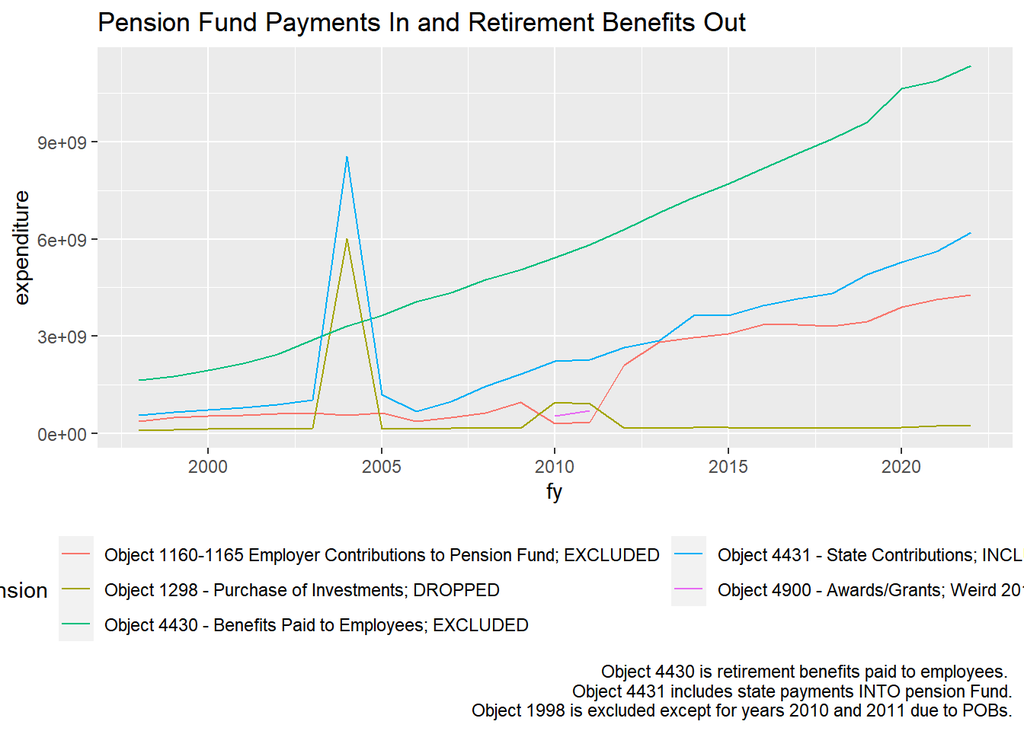

```r
# check what is being included in pensions

# funds related to pension contributions
pension_funds <- c("0472", "0473", "0477", "0479", "0481", "0755", "0786", "0787", "0788", "0789", "0799")

pension_check <- exp_temp %>%
  mutate(pension = case_when(
 # object == "4430" & fund == "0825" ~ "Object 4430 - Pension Buyout/Benefits Paid Early",
    (object=="4430") ~ "Object 4430 - Benefits Paid to Employees; EXCLUDED", # pensions, annuities, benefits
    (object=="4431") ~ "Object 4431 - State Contributions; INCLUDED", # 4431 = state payments into pension fund
        (obj_seq_type > "11590000" & obj_seq_type < "11660000")  ~ "Object 1160-1165 Employer Contributions to Pension Fund; EXCLUDED",
    # objects 1159 to 1166 are all considered Retirement by Comptroller

            TRUE ~ "0")) %>%  # All other observations coded as 0 for non-pension items

  # recodes specific instances of code anomalies from past years:
  mutate(pension = case_when(
    (object=="1298" & fund %in% pension_funds ) ~ "Object 1298 - Purchase of Investments; DROPPED",


      # pension stabilization fund in 2022
 # object == "1900" & fund == "0319" ~ "Fund 0319-Pension Stabilization",
    object == "1900" & fund %in% pension_funds ~ "Fund 0319 - Pension Stabilization",


  object == "4900" & fund %in% pension_funds ~ "Object 4900 - Awards/Grants; Weird 2010-2011 values",

    TRUE ~ as.character(pension)) ) %>%
  filter(pension != "0" )

pension_check %>% group_by(fy, pension) %>%
  summarize(expenditure = sum(expenditure, na.rm = TRUE)) %>%
  ggplot(aes(x=fy, y = expenditure, color = pension)) +
  geom_line() +

  labs (title = "Pension Fund Payments In and Retirement Benefits Out",
  caption = "Object 4430 is retirement benefits paid to employees.
  Object 4431 includes state payments INTO pension Fund.
  Object 1998 is excluded except for years 2010 and 2011 due to POBs.")+
    theme(legend.position = "bottom")+
  guides(color = guide_legend(nrow=3))
```

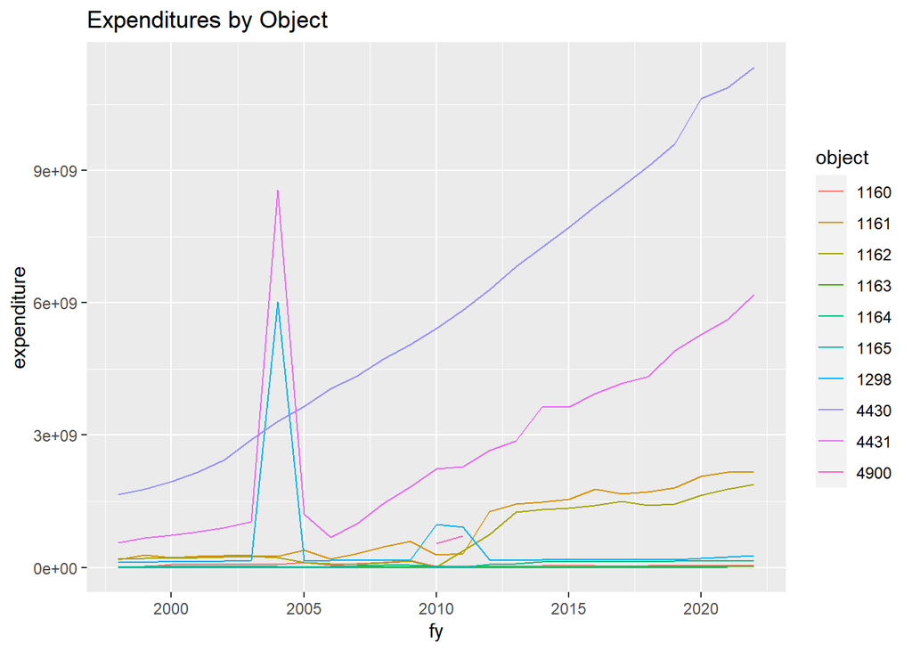

```r
pension_check %>% group_by(fy, object) %>%
  summarize(expenditure = sum(expenditure, na.rm = TRUE)) %>%
  ggplot(aes(x=fy, y = expenditure, color = object)) +
  geom_line() +
  labs (title = "Expenditures by Object")
```

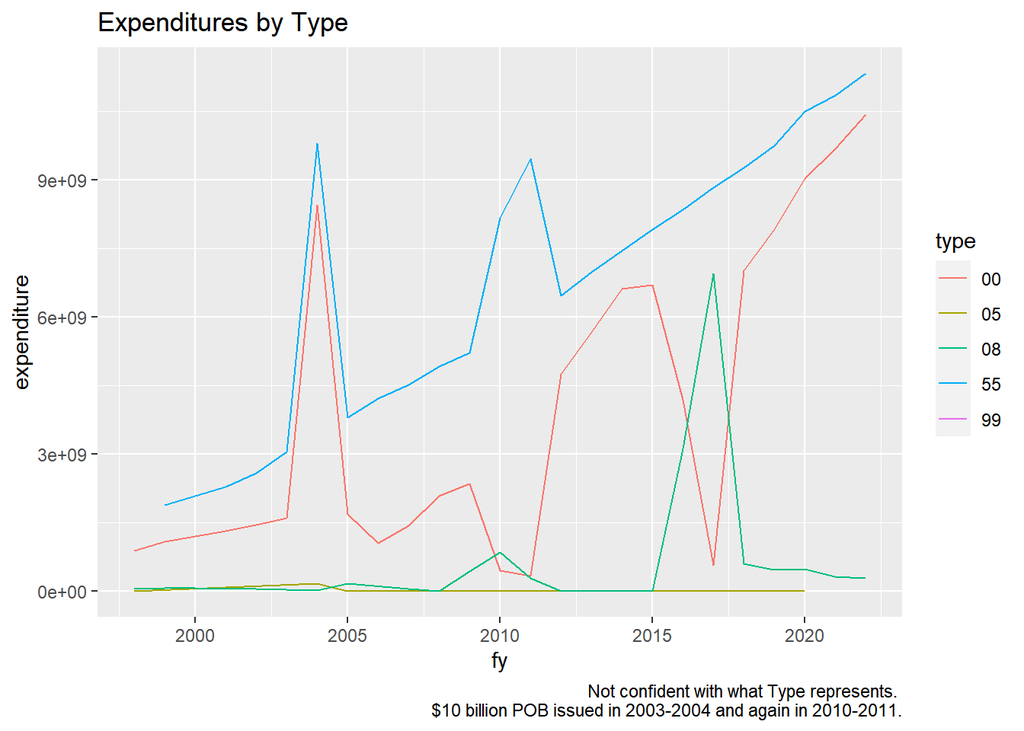

```r
pension_check %>% group_by(fy, type) %>%
  summarize(expenditure = sum(expenditure, na.rm = TRUE)) %>%
  ggplot(aes(x=fy, y = expenditure, color = type)) +
  geom_line() +
  labs (title = "Expenditures by Type", caption = "Not confident with what Type represents.
        $10 billion POB issued in 2003-2004 and again in 2010-2011.")
```

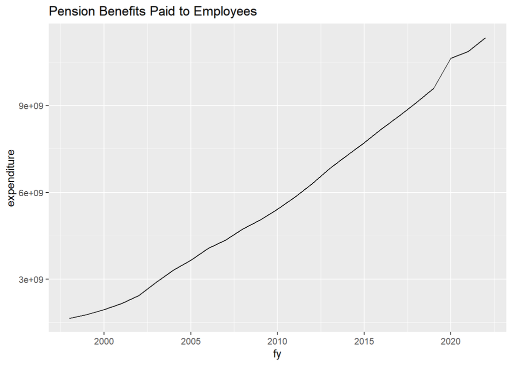

```r
pension_check3 <- exp_temp %>%
  mutate(pension = case_when(
       (object=="4430"  ) ~ 1, # 4430 = pension benefits paid to retired employees
            TRUE ~ 0)) %>%
  filter(pension > 0 )

pension_check3 %>% group_by(fy) %>%
  summarize(expenditure = sum(expenditure, na.rm = TRUE)) %>%
  ggplot(aes(x=fy, y = expenditure)) +
  geom_line() +
  labs (title = "Pension Benefits Paid to Employees")
```

```r
## taking care of Pension Obligation Bond proceeds
```

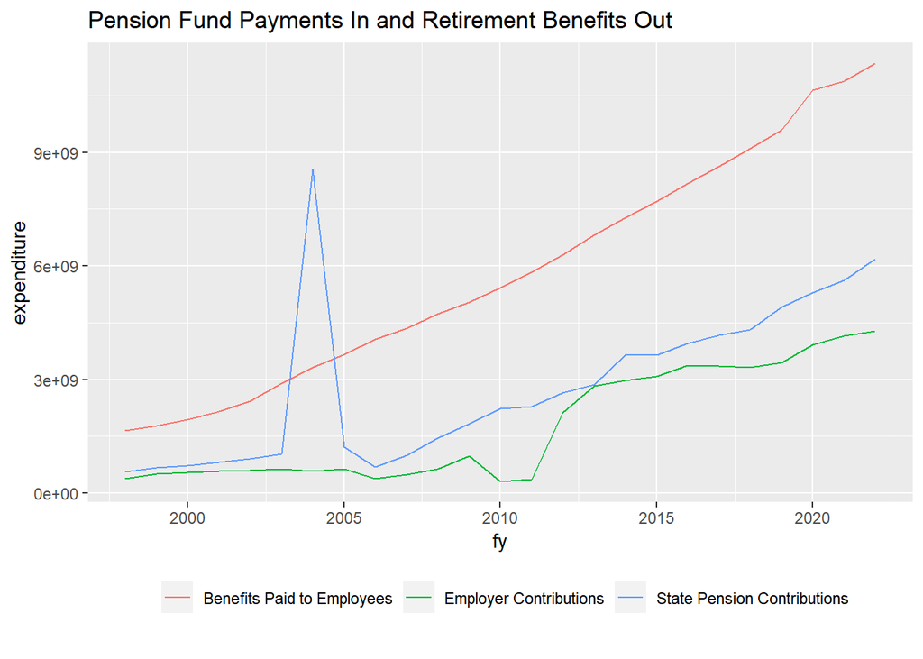

```r
pension_picture <- exp_temp %>%
  mutate(pension = case_when(
  #object == "4430" & fund == "0825" ~ "Pension Buyout/Benefits Paid Early; INCLUDED",
    (object=="4430") ~ "Benefits Paid to Employees", # pensions, annuities, benefits
    (object=="4431") ~ "State Pension Contributions", # 4431 = state payments into pension fund
        (obj_seq_type > "11590000" & obj_seq_type < "11660000")  ~ "Employer Contributions",
    # objects 1159 to 1166 are all considered Retirement by Comptroller

            TRUE ~ "0")) %>%  # All other observations coded as 0 for non-pension items

  # recodes specific instances of code anomalies from past years:
#  mutate(pension = case_when( (object=="1298" & fund %in% pension_funds ) ~ "Purchase of Investments",


      # pension stabilization fund in 2022
 # object == "1900" & fund == "0319" ~ "Fund 0319-Pension Stabilization",
   # object == "1900" & fund %in% pension_funds ~ "Pension Stabilization Fund",

    #TRUE ~ as.character(pension)) ) %>%
  filter(pension != "0" )

pension_picture %>% group_by(fy, pension) %>%
  summarize(expenditure = sum(expenditure, na.rm = TRUE)) %>%
  ggplot(aes(x=fy, y = expenditure, color = pension)) +
  geom_line() +

  labs (title = "Pension Fund Payments In and Retirement Benefits Out",
  caption = "")+
    theme(legend.position = "bottom", legend.title = element_blank())#+ guides(color = guide_legend(nrow=2))
```

Employer contributions and state pension contributions are an example of an expenditure being double counted if both are included.

### Pension Contributions

rev_type = 51 is for retirement/pension contributions from both employers and employees. These contributions from employers and employees are not considered a revenue source from the state and are excluded from the Fiscal Futures analysis. However, it is still important to understand the money going in and out of then pension funds even if it is not included as a yearly expenditure or revenue. Retirement contribution revenue is graphed below.

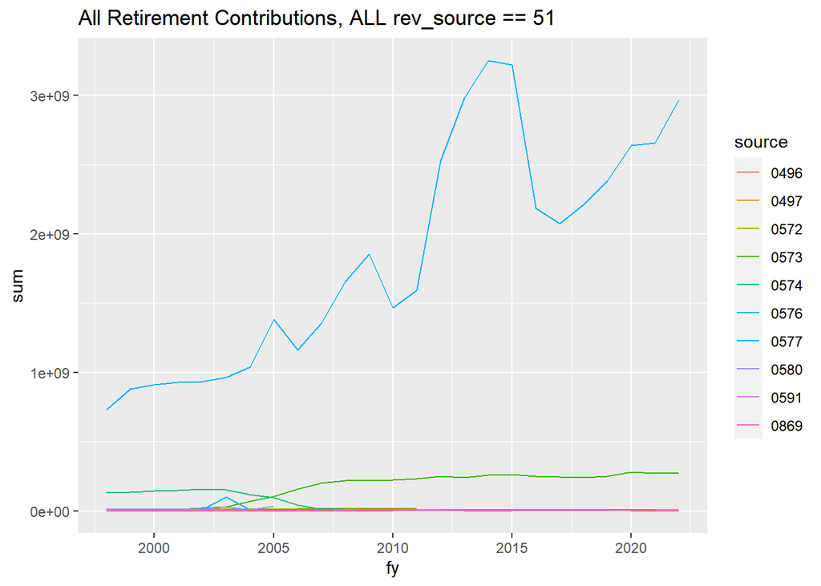

```r
# current year employee revenue source = 0573, contributions by employee == 572 (stops at 2011)
retirement_contributions <- rev_temp %>%
  filter(rev_type == "51") %>% group_by(fy) %>% summarize(contributions = sum(receipts))

employer_contributions <- rev_temp %>%
  filter(rev_type == "51" & source == "0577") %>% group_by(fy) %>% summarize(contributions = sum(receipts))

employee_contributions <- rev_temp %>%
  filter(rev_type == "51" & (source == "0572" | source == "0573") ) %>%
  group_by(fy) %>% summarize(contributions = sum(receipts))

benefits_paid <- pension_check %>% filter(object == "4430") %>%
  group_by(fy) %>%
  summarize(expenditure = sum(expenditure, na.rm = TRUE))

state_contrib <- pension_check %>% filter(object == "4431") %>%
  group_by(fy) %>%
  summarize(expenditure = sum(expenditure, na.rm = TRUE))

rev_temp %>%
  filter(rev_type == "51") %>% # all retirement contributions
  group_by(fy, source) %>%
  summarise(sum = sum(receipts, na.rm = TRUE)) %>%
  ggplot() +
  geom_line(aes(x=fy, y = sum, color=source)) + labs(title="All Retirement Contributions, ALL rev_source == 51")
```

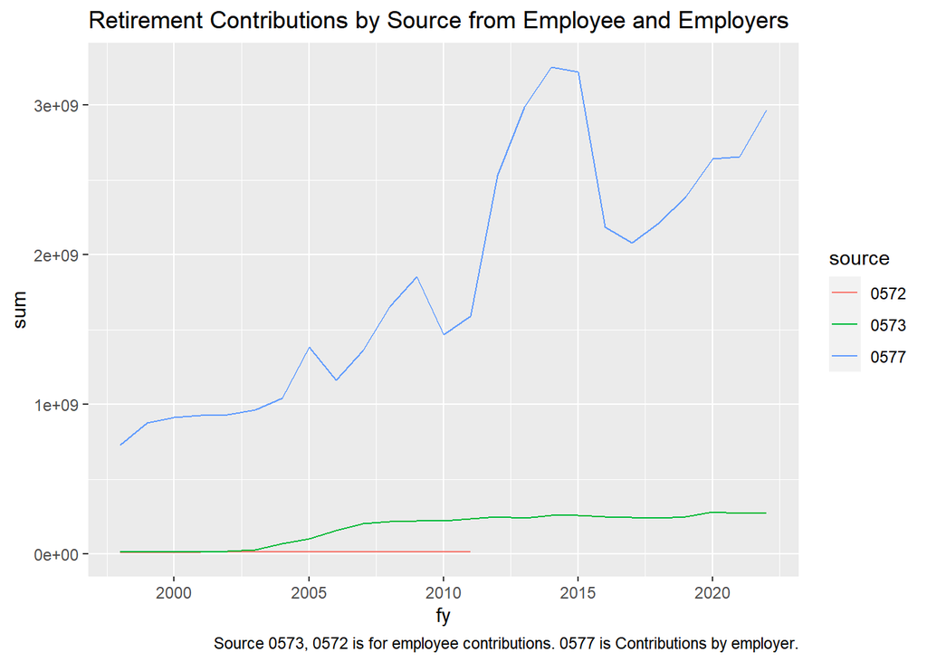

```r
rev_temp %>%
  filter(rev_type == "51" & source == "0573" | source == "0572" | source == "0577") %>%
  group_by(fy, source) %>%
  summarise(sum = sum(receipts, na.rm = TRUE)) %>%
  ggplot() +
  geom_line(aes(x=fy, y = sum, color=source)) + labs(title="Retirement Contributions by Source from Employee and Employers", caption = "Source 0573, 0572 is for employee contributions. 0577 is Contributions by employer.")
```

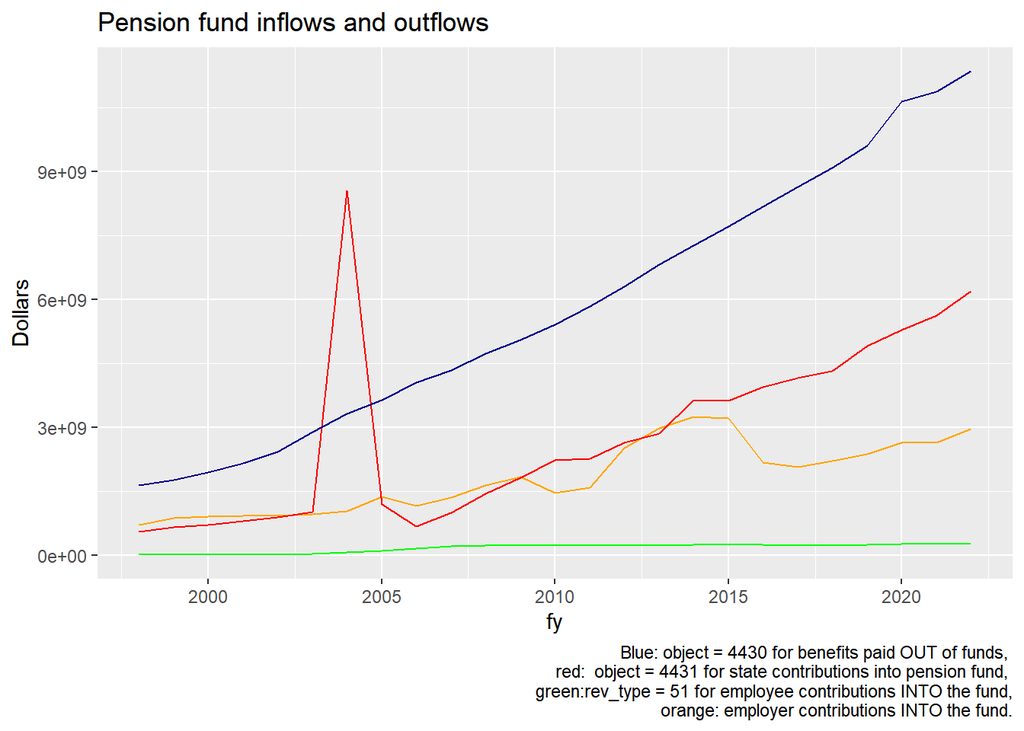

```r
# contributions and benefits paid comparison
ggplot()+
  geom_line(data=employee_contributions, aes(x=fy, y=contributions), color="green") +
    geom_line(data=employer_contributions, aes(x=fy, y=contributions), color="orange") +

  geom_line(data= state_contrib, aes(x=fy, y = expenditure), color = "red")+

  geom_line(data= benefits_paid, aes(x=fy, y = expenditure), color = "dark blue")+
  labs(title="Pension fund inflows and outflows",
       caption = "Blue: object = 4430 for benefits paid OUT of funds,
      red:  object = 4431 for state contributions into pension fund,
     green:rev_type = 51 for employee contributions INTO the fund,
     orange: employer contributions INTO the fund.", y = "Dollars")
```

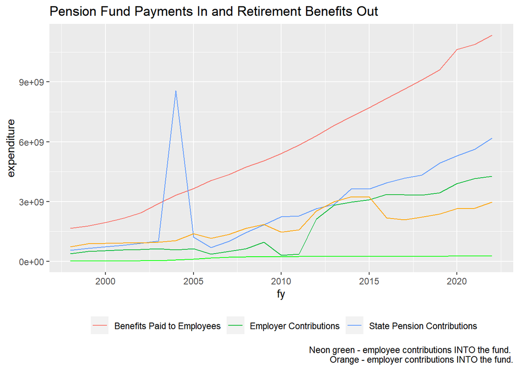

```r
pension_picture %>% group_by(fy, pension) %>%
  summarize(expenditure = sum(expenditure, na.rm = TRUE)) %>%
  ggplot(aes(x=fy, y = expenditure, color = pension)) +
  geom_line() +
  geom_line(data=employee_contributions, aes(x=fy, y=contributions), color="green") +
    geom_line(data=employer_contributions, aes(x=fy, y=contributions), color="orange") +
  labs (title = "Pension Fund Payments In and Retirement Benefits Out",
  caption = "Neon green - employee contributions INTO the fund.
  Orange - employer contributions INTO the fund.")+
    theme(legend.position = "bottom", legend.title = element_blank())
```

## Debt Service Discussion

Debt Service expenditures include interest payment on both short-term and long-term debt. We do not include escrow or principal payments.

**Decision from Sept 30 2022:** We are no longer including short term principal payments as a cost; only interest on borrowing is a cost. Pre FY22 and the FY21 correction, we did include an escrow payment and principle payments as costs but not bond proceeds as revenues. This caused expenditures to be inflated because we were essentially counting debt twice - the principle payment and whatever the money was spent on in other expenditure categories, which was incorrect.

**Objects:**  
8813 interest **INCLUDE AS COST**  
8811 is for principle **EXCLUDE from aggregate debt expenditure**  
8841 is for escrow payments **EXCLUDE from aggregate debt expenditure**  
8800 is for capital projects debt service (e.g. Build Illinois Bonds, Civic Center, Tollway **EXCLUDE tollway in debt cost** - Note: debt principle and interest are both included in capital projects because they are combined in the data observations; bond proceeds are not considered a revenue source. Can’t include capital projects interest as easily as the GO bonds.

**Obj_seq_type:**  
- Exclude: Bond principle payments: obj_seq_type == 88110008  
- Exclude: Short term borrowing principle: obj_seq_type == 88110108  
- Include: General Obligation Bond Interest: obj_seq_type == 88130000 & 88130008  
- Include: Interest on short-term borrowing: 88130108  
- Exclude: Escrow payment == 88410008  
- Include: Build IL Bonds, capital projects principal AND interest  
- Tollway is obj_seq_type == 88000055, filter out fund == 0455 to remove tollway  
- fund == 0455 is the IL State Toll Highway fund, items mostly for operations and maintenance

```r
tollway <- exp_temp %>% filter(fund == "0455") #all tollway expenditures
capitalproject_debtservice <- exp_temp %>%filter(object == "8800") # ALL Capital projects debt service

# look at Illinois tollway bond proceeds and debt service:
# rev_temp %>% filter(fund == "0455") # examine items in fund 0455
#exp_temp %>% filter(fund == "0455") %>% group_by(fy) %>% summarize(sum = sum(expenditure)) %>% arrange(-fy)
tollway
```

[output not shown]

[output cut: 225 more lines]

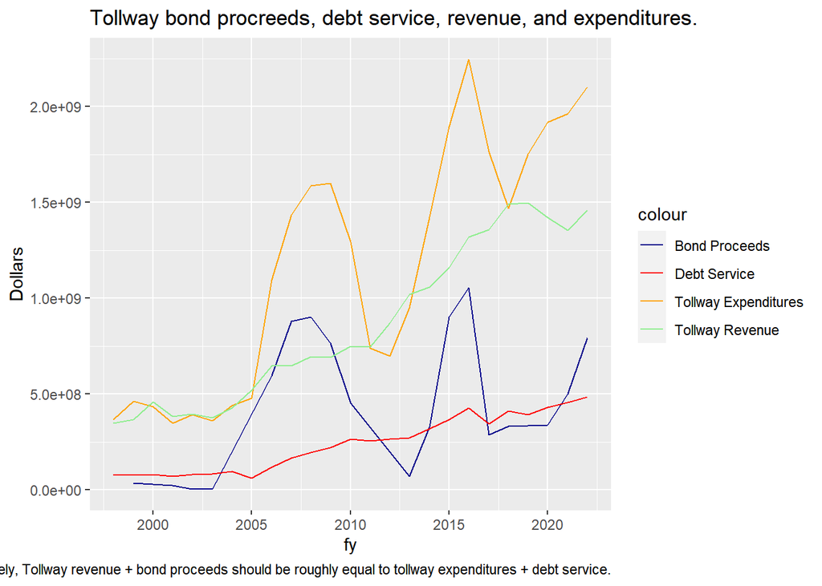

```r
#rev_temp %>% filter(fund == "0455") %>% group_by(fy) %>% summarize(sum = sum(receipts)) %>% arrange(-fy)


tollway_exp <- exp_temp %>% filter(fund == "0455") %>% group_by(fy) %>% summarize(expenditure = sum(expenditure))
                                                                                                    #tollway_exp %>% ggplot() + geom_line(aes(x=fy, y=expenditure)) + labs(title = "Fund 0455 from Expenditure: All Tollway Expenditures", caption = "Data from IOC Expenditure Files. Fund 0455 is the IL State Tollway")


# all tollway revenues, not just bond proceeds
alltollway<-rev_temp %>% filter(fund == "0455" & source != "0571") %>% group_by(fy) %>% summarize(sum = sum(receipts, na.rm = TRUE))


# tollway bond proceeds
tollway_bondproc <- rev_temp %>% filter(fund == "0455" & source == "0571" ) %>% group_by(fy) %>% summarize(sum = sum(receipts, na.rm = TRUE))

#alltollway %>%  ggplot() + geom_line(aes(x=fy, y=sum)) + labs(title = "Fund 0455 - All Tollway Revenue", caption = "Data from IOC Revenue Files. Fund 0455 is the IL State Tollway Revenue")

#tollway_bondproc %>% ggplot() + geom_line(aes(x=fy, y=sum)) + labs(title = "Fund 0455 - Tollway Revenue: Tollway Bond Proceeds", caption = "Data from IOC Revenue Files. Fund 0455 is the IL State Tollway Revenue")

#ggplot() + geom_line(data=tollway_bondproc, aes(x=fy, y=sum)) + labs(title = "Fund 0455 - Tollway Revenue: Tollway Bond Proceeds", caption = "Data from IOC Revenue Files. Fund 0455 is the IL State Tollway Revenue")

#tollwaydebt %>% ggplot() + geom_line(aes(x=fy, y=sum)) + labs(title = "Tollway Debt Service", caption = "Debt service includes principal and interest for the Illinois Tollway. Object = 8800 and fund = 0455")


#tollway debt principal and interest
tollwaydebt <- exp_temp %>%filter(object == "8800" & fund == "0455") %>% group_by(fy) %>% summarize(sum=sum(expenditure))

# Tollway agency expenditures = SAME as filtering by fund == 0455
#tollway<-exp_temp %>% filter(agency == "557")
#exp_temp %>% filter(agency == "557") %>% group_by(fy) %>% summarize(sum = sum(expenditure)) %>% arrange(-fy)

# contributions and benefits paid comparison
ggplot()+
  geom_line(data=tollway_bondproc, aes(x=fy, y=sum, color='Bond Proceeds')) +
  geom_line(data= tollwaydebt, aes(x=fy, y = sum, color = 'Debt Service'))+
  geom_line(data= tollway_exp, aes(x=fy, y = expenditure, color = 'Tollway Expenditures'))+
  geom_line(data= alltollway, aes(x=fy, y = sum, color = "Tollway Revenue"))+
  scale_color_manual(values = c(
    'Bond Proceeds' = 'darkblue',
    'Debt Service' = 'red',
    'Tollway Expenditures' = 'orange',
    'Tollway Revenue' = 'light green')) +
  labs(title="Tollway bond procreeds, debt service, revenue, and expenditures.",
       caption = "Intuitively, Tollway revenue + bond proceeds should be roughly equal to tollway expenditures + debt service.",
       y = "Dollars")
```

Looking only at general obligation principal payments and interest payments:

```r
# GO bond principal and GO bond interest
GObond_debt <- exp_temp %>%
  filter(obj_seq_type == "88110008" |obj_seq_type == "88130000" | obj_seq_type == "88130008") %>%
  group_by(fy, obj_seq_type) %>%
  summarize(sum = sum(expenditure, na.rm=TRUE)) %>%
  pivot_wider(names_from = obj_seq_type, values_from = sum) %>%
  mutate(principal = `88110008`,
         interest = sum(`88130008`+`88130000`, na.rm = TRUE),
         ratio = (as.numeric(interest)/as.numeric(principal)))

GObond_debt %>% select(principal, interest, ratio) %>%
  mutate(across(principal:interest, ~format(., big.mark= ",", scientific = F)))
```

| fy | principal | interest | ratio |
| --- | --- | --- | --- |
| 1998 | 148,066,200 | 259,385,877 | 1.751824 |
| 1999 | 2,999,040 | 267,956,231 | 89.347335 |
| 2000 | 1,000,000 | 287,154,654 | 287.154654 |
| 2001 | 154,166,026 | 0 | 0.000000 |
| 2002 | 271,518,687 | 0 | 0.000000 |
| 2003 | 138,351,231 | 0 | 0.000000 |
| 2004 | 21,400,000 | 997,469,105 | 46.610706 |
| 2005 | 37,400,000 | 1,061,205,268 | 28.374472 |
| 2006 | 1,000,000,000 | 1,113,124,277 | 1.113124 |
| 2007 | 6,995,000 | 1,115,485,186 | 159.468933 |

[output cut: 15 more lines]

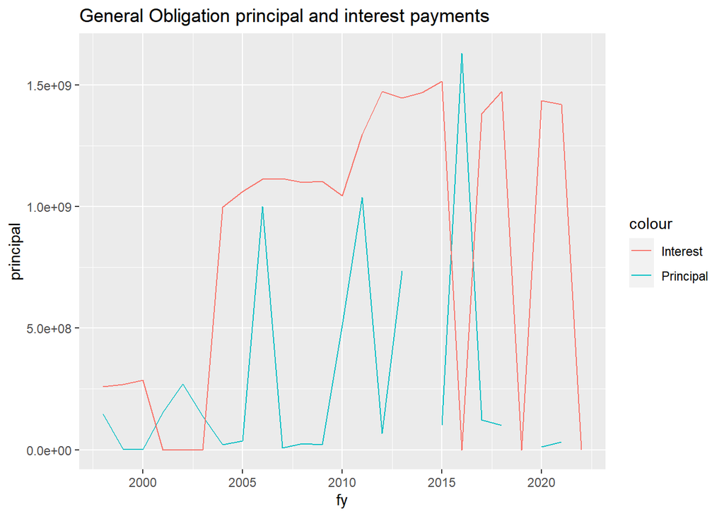

```r
GObond_debt %>% ggplot() +
  geom_line(aes(x=fy, y=principal, color = "Principal"))+
  geom_line(aes(x=fy, y=interest, color = "Interest")) +
  labs(title = "General Obligation principal and interest payments")
```

Looking only at short term borrowing principal and interest payments:

```r
# short term borrowing, first observation is in 2004?
short_debt <- exp_temp %>%
  filter(obj_seq_type == 88110108 |obj_seq_type == 88130108) %>%
  group_by(fy, obj_seq_type) %>%
  summarize(sum = sum(expenditure, na.rm=TRUE)) %>%
  pivot_wider(names_from = obj_seq_type, values_from = sum) %>%
  mutate(principal = `88110108`,
         interest = `88130108`,
         ratio = (as.numeric(interest)/as.numeric(principal)))

short_debt %>% select(principal, interest, ratio) %>%
  mutate(across(principal:interest, ~format(., big.mark= ",",  scientific = F)))
```

| fy | principal | interest | ratio |
| --- | --- | --- | --- |
| 2004 | 1,500,000,000 | 22,364,583 | 0.014909722 |
| 2005 | 1,615,000,000 | 10,672,222 | 0.006608187 |
| 2007 | 900,000,000 | NA | NA |
| 2008 | 1,200,000,000 | 6,233,333 | 0.005194444 |
| 2009 | 1,400,000,000 | 26,675,000 | 0.019053571 |
| 2010 | 2,250,000,000 | 55,277,778 | 0.024567901 |
| 2011 | 1,300,000,000 | 30,975,000 | 0.023826923 |
| 2021 | 2,184,745,000 | 51,007,557 | 0.023347144 |
| 2022 | 1,164,255,000 | 90,437,183 | 0.077678157 |

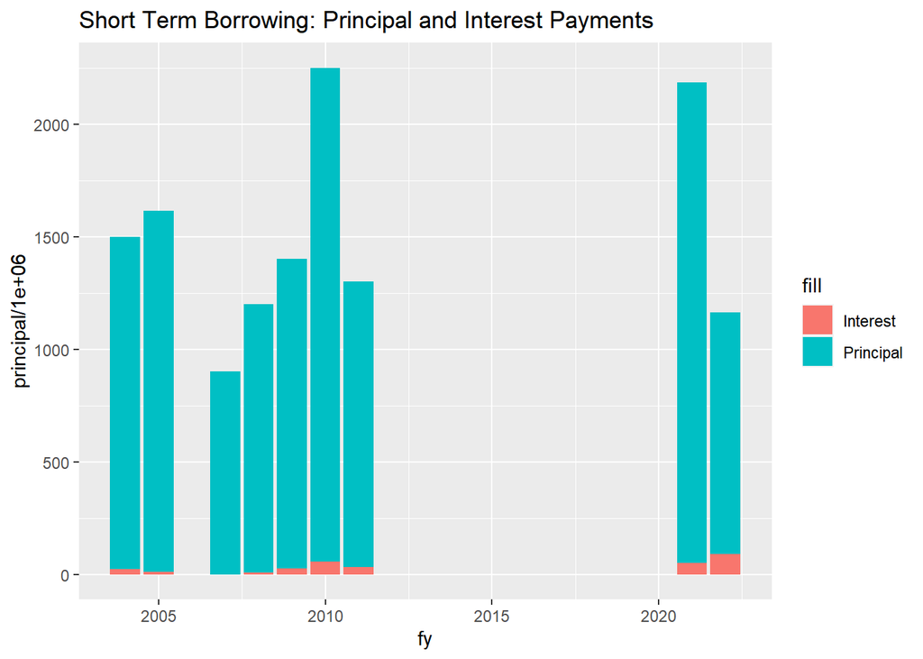

```r
short_debt %>% ggplot() +
  geom_col(aes(x=fy, y=principal/1000000, fill = "Principal"))+
  geom_col(aes(x=fy, y=interest/1000000, fill = "Interest")) +
  labs(title = "Short Term Borrowing: Principal and Interest Payments")
```

Principal and interest amounts calculated exclude the Illinois Tollway debt service and debt for capital projects. Capital projects debt service is examined below:

```r
capitalprojects <- exp_temp %>%filter(object == "8800")

all_debt <- exp_temp %>%
  filter(fund != "0455" & (object == "8811" |object == "8813" | object == "8800") )%>%
  group_by(fy, object) %>%
  summarize(sum = sum(expenditure, na.rm=TRUE)) %>%
  pivot_wider(names_from = object, values_from = sum) %>%
  mutate(principal = `8811`,
         interest = `8813`,
         CapitalProjects = `8800`,
         ratio = (as.numeric(interest)/as.numeric(principal)))

all_debt %>% select(principal, interest, CapitalProjects, ratio) %>%
  mutate(across(principal:CapitalProjects, ~format(., big.mark= ",", scientific = F)))
```

| fy | principal | interest | CapitalProjects | ratio |
| --- | --- | --- | --- | --- |
| 1998 | 575,371,231 | 259,385,877 | 225,148,458 | 0.4508148 |
| 1999 | 422,975,040 | 267,956,231 | 239,571,392 | 0.6335036 |
| 2000 | 430,464,406 | 287,154,654 | 256,685,875 | 0.6670811 |
| 2001 | 585,553,477 | 336,582,816 | 253,461,423 | 0.5748114 |
| 2002 | 740,370,036 | 382,634,975 | 257,622,074 | 0.5168159 |
| 2003 | 1,658,569,732 | 474,937,865 | 256,264,319 | 0.2863539 |
| 2004 | 1,923,668,657 | 1,019,833,688 | 268,750,574 | 0.5301504 |
| 2005 | 2,153,260,524 | 1,071,877,490 | 279,939,826 | 0.4977928 |
| 2006 | 1,565,449,887 | 1,113,124,277 | 302,328,995 | 0.7110571 |
| 2007 | 1,477,592,635 | 1,115,485,186 | 301,723,144 | 0.7549342 |

[output cut: 15 more lines]

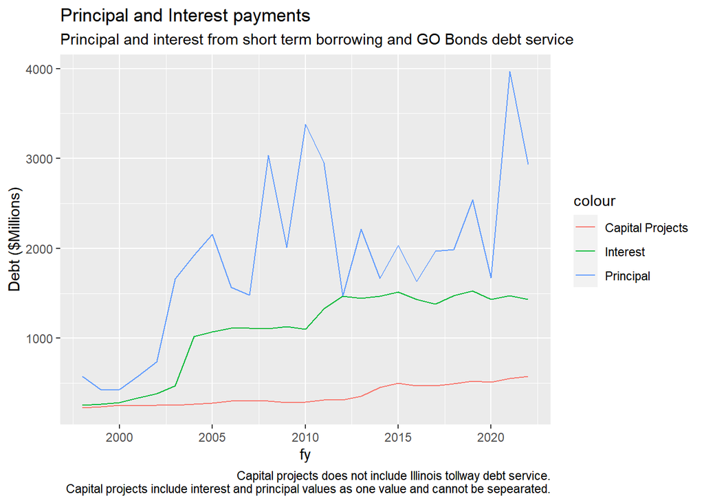

```r
all_debt %>% ggplot() +
  geom_line(aes(x=fy, y=principal/1000000, color = "Principal"))+
  geom_line(aes(x=fy, y=interest/1000000, color = "Interest"))+
  geom_line(aes(x=fy, y = CapitalProjects / 1000000, color = "Capital Projects"))+
  labs(y = "Debt ($Millions)",
       title = "Principal and Interest payments", subtitle = "Principal and interest from short term borrowing and GO Bonds debt service", caption = "Capital projects does not include Illinois tollway debt service.
       Capital projects include interest and principal values as one value and cannot be sepearated.")
```

Capital projects include the IL Civic Center and Build Illinois Bonds. Tollway principal and interest has been dropped from the State’s Debt Service expenditure but is counted in the Illinois Tollway Expenditure cost.

## State Employee Healthcare Discussion

State Employee Health Care = Sum of expenditures for “health care coverage as elected by members per state employees group insurance act.” The payments are made from the Health Insurance Reserve Fund. Employee contributions are not considered a revenue source or an expenditure in our analysis.

**Coding details**  
In FY2013, the Local Government Health Insurance fund was transferred to the department of Central Management Services (agency changes from 478 to 416 in data.)

Employer group insurance contributions for health insurance are excluded to avoid double counting the cost of healthcare provision. All employer group insurance contributions are coded as object = 1180. BUT the last two fiscal years were coded as 1900 instead of 1180 for lump sums instead of employer contributions  
- anything to do with pandemic money categorization?

Fund = 0457 is “Group insurance premium”, in_ff = 1  
Fund = 0193 is “Local govt health insurance reserve”, in=ff = 0  
fund = 0477 is “Community College Health Insurance”, in=ff = 0.  
- had large amount in early years  
Fund = 0907 = health insurance reserve, in_ff = 1  
Fund = 9939 is “group self-insurers’ insolv”, in_ff = 1  
Fund = 0940 is Self-Insurers security, in_ff = 0  
Fund = 0739 is Group Workers Comp Pool Insol, in_ff = 1

- eehc = 0 means it is NOT a state healthcare cost but it is an employer contribution of some type to some fund
- eehc = 1 means it is a state employee healthcare cost and it is an employer contribution to health insurance

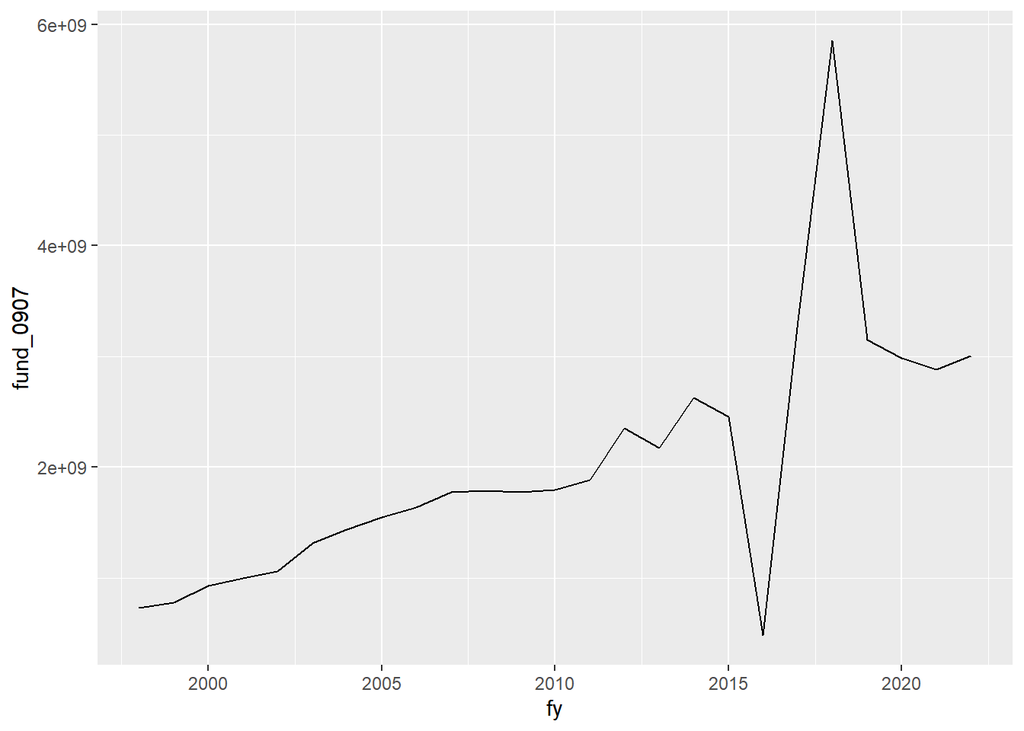

```r
health_ins_reserve <- exp_temp %>% filter(fund == "0907") %>%  group_by(fy) %>%
    summarize(fund_0907 = sum(expenditure))

health_ins_reserve %>%
  ggplot(aes(x=fy, y=fund_0907)) + geom_line()
```

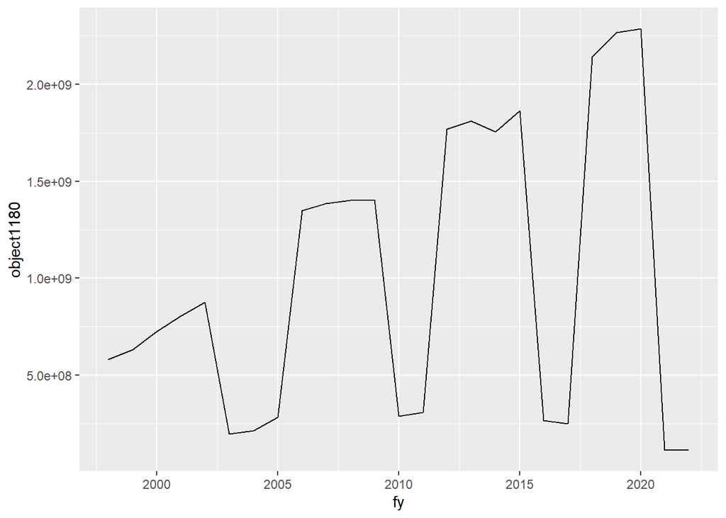

```r
# object 1180 is inconsistently coded over time form the IOC
# object 1180 should be employer contributions to healthcare group insurance
employer_contributions <- exp_temp %>% filter(object == "1180") %>% group_by(fy) %>% summarize(object1180 = sum(expenditure))

employer_contributions%>%
  ggplot(aes(x=fy, y=object1180)) + geom_line()
```

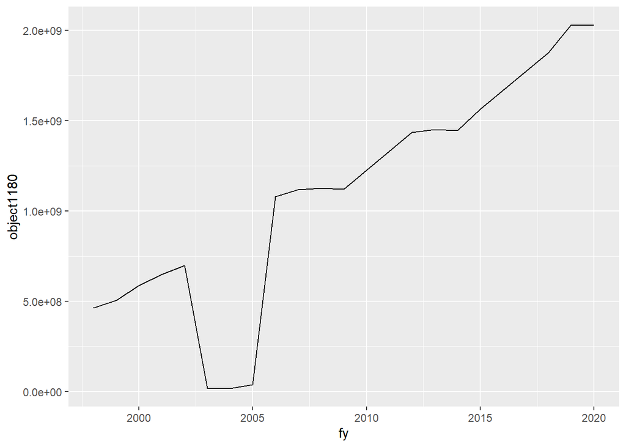

```r
employer_contributions2 <- exp_temp %>% filter(object == "1180" & fund=="0001") %>% group_by(fy) %>% summarize(object1180 = sum(expenditure))

employer_contributions2 %>%
  ggplot(aes(x=fy, y=object1180)) + geom_line()
```

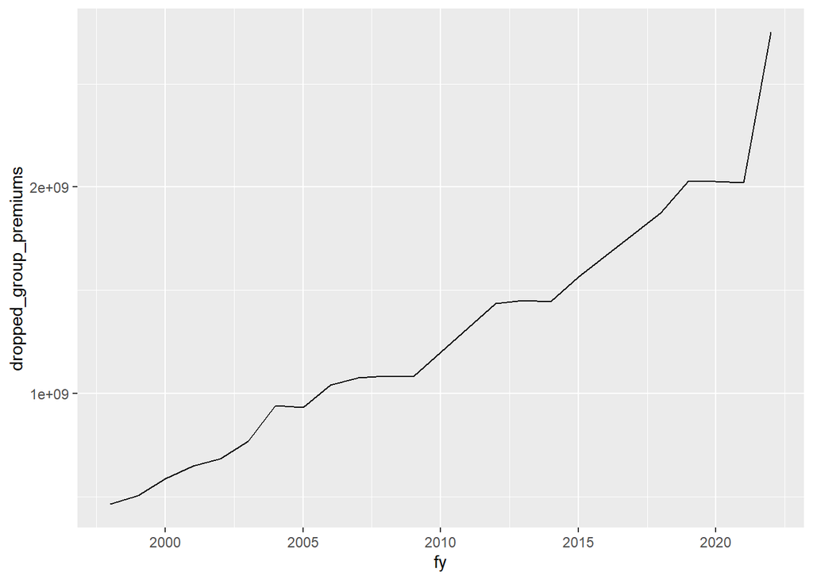

```r
# examine group insurance totals per year
group_ins2 <- exp_temp %>%
  mutate(eehc = ifelse(
    # group insurance contributions for 1998-2005 and 2013-present
    # CMS took over health insurance in 2013
   fund == "0001" & (object == "1180" | object =="1900") & agency == "416" & appr_org=="20", 1, 0) )%>%
  mutate(eehc = ifelse(
    # group insurance contributions for 2006-2012
    # health insurance was in healthcare and family services, agency 478 for a few years
    fund == "0001" & object == "1180" & agency == "478" & appr_org=="80", 1, eehc) )%>%
  filter(eehc == 1) %>%
    group_by(fy) %>%
    summarize(dropped_group_premiums = sum(expenditure))


group_ins2 %>% ggplot(aes(x=fy, y=dropped_group_premiums)) + geom_line()
```

If observation is a group insurance contribution, then the expenditure amount is set to $0 (essentially dropped from analysis).

### Health Insurance Premiums from Employees

Employee insurance premiums for healthcare are a revenue source for the state in the IOC data but are not included the Fiscal Futures analysis and fiscal gap calculations.

> Last month I said: In order to get the true cost of State Employee Healthcare, total employee insurance premiums should be subtracted from the healthcare expenditure total (exp_904 - premiums). Gather all employee premiums into `emp_premiums` and subtract it from the Expenditure table after aggregating and pivoting steps.

0120 = ins prem-option life 0120 = ins prem-optional life/univ 0347 = optional health - HMO 0348 = optional health - dental 0349 = optional health - univ/local SI 0350 = optional health - univ/local 0351 = optional health - retirement 0352 = optional health - retirement SI 0353 = optional health - retire/dental 0354 = optional health - retirement hmo

2199-2209 = various HMOs, dental, health plans from Health Insurance Reserve (fund)

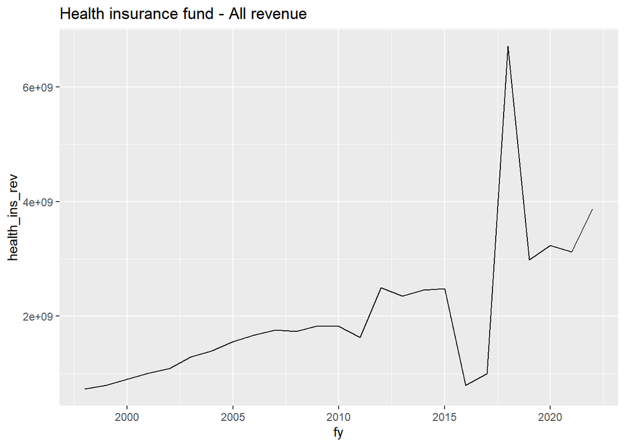

```r
health_insurance_fund_rev<- rev_temp %>%
  filter(fund=="0907") %>%
    group_by(fy) %>%
  summarize(health_ins_rev = sum(receipts))

health_insurance_fund_rev %>%
  ggplot(aes(x=fy, y = health_ins_rev)) +
  geom_line() + labs( title = "Health insurance fund - All revenue")
```

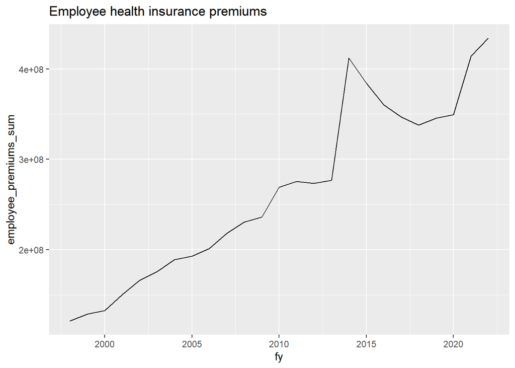

```r
#collect optional insurance premiums to fund 0907 for use in eehc expenditure
employee_health_premiums <- rev_temp %>%
  mutate(employee_premiums = ifelse(
    fund=="0907" & (source=="0120"| source=="0121"| (source>"0345" & source<"0357")|(source>"2199" & source<"2209")), 1, 0)) %>%
  filter(employee_premiums == 1)

# optional insurance premiums = employee insurance premiums
emp_premium <- employee_health_premiums %>%
  group_by(fy) %>%
  summarize(employee_premiums_sum = sum(receipts))

emp_premium %>% ggplot(aes(x=fy, y = employee_premiums_sum)) +
  geom_line() + labs( title = "Employee health insurance premiums")
```

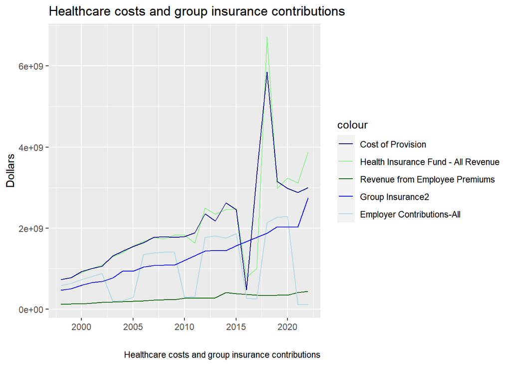

```r
# contributions and benefits paid comparison
ggplot()+
  #  geom_line(data=group_ins, aes(x=fy, y=object1180, color='Group Insurance1')) +
      geom_line(data=health_insurance_fund_rev, aes(x=fy, y=health_ins_rev, color='Health Insurance Fund - All Revenue')) +
 geom_line(data = emp_premium, aes(x=fy, y = employee_premiums_sum, color = 'Revenue from Employee Premiums')) +
    geom_line(data=health_ins_reserve, aes(x=fy, y=fund_0907, color='Cost of Provision')) +
    geom_line(data=employer_contributions, aes(x=fy, y=object1180, color='Employer Contributions-All')) +
 #   geom_line(data=employer_contributions2, aes(x=fy, y=object1180, color='Employer Contributions-General Fund')) +

  geom_line(data=group_ins2, aes(x=fy, y=dropped_group_premiums, color='Group Insurance2')) +
  #geom_line(data= healthcare_costs, aes(x=fy, y = cost_of_provision, color = 'Healthcare Costs'))+
  scale_color_manual(values = c(
    'Cost of Provision' = 'darkblue',
    'Health Insurance Fund - All Revenue' = 'light green',
    'Revenue from Employee Premiums' = 'dark green',
    'Group Insurance2' = 'blue',
    'Employer Contributions-All' = 'light blue'
   #     'Employer Contributions-General Fund' = 'light blue'
)) +
  labs(title="Healthcare costs and group insurance contributions",
       caption = "Healthcare costs and group insurance contributions",
       y = "Dollars", x = "")
```

# Expenditure & Revenue Categorization

## Modify Expenditure File

### Tax refunds

Aggregate expenditures: Save tax refunds as negative revenue. Code refunds to match the rev_type codes (02=income taxes, 03 = corporate income taxes, 06=sales tax, 09=motor fuel tax, 24=insurance taxes and fees, 35 = all other tax refunds).

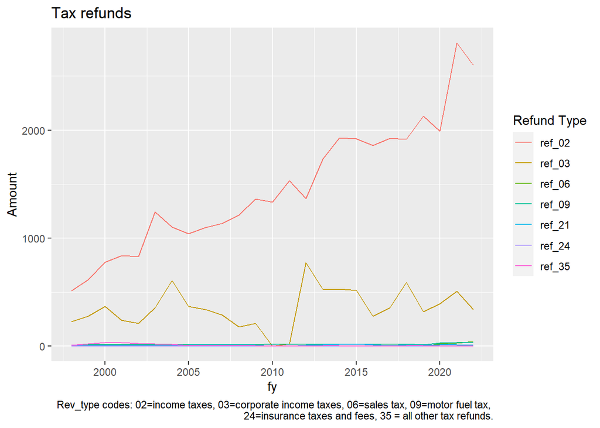

```r
## negative revenue becomes tax refunds

tax_refund_long <- exp_temp %>%           # fund != "0401" # removes State Trust Funds
  filter(fund != "0401" & (object=="9910"|object=="9921"|object=="9923"|object=="9925")) %>%
  # keeps these objects which represent revenue, insurance, treasurer,and financial and professional reg tax refunds
  mutate(refund = case_when(
    fund=="0278" & sequence == "00" ~ "02", # for income tax refund
    fund=="0278" & sequence == "01" ~ "03", # tax administration and enforcement and tax operations become corporate income tax refund
     fund == "0278" & sequence == "02" ~ "02",
    object=="9921" ~ "21",                # inheritance tax and estate tax refund appropriation
    object=="9923" ~ "09",                # motor fuel tax refunds
    obj_seq_type == "99250055" ~ "06",    # sales tax refund
    fund=="0378" & object=="9925" ~ "24", # insurance privilege tax refund
    fund=="0001" & object=="9925" ~ "35", # all other taxes
      T ~ "CHECK"))                       # if none of the items above apply to the observations, then code them as CHECK


exp_temp <- left_join(exp_temp, tax_refund_long) %>%
  mutate(refund = ifelse(is.na(refund),"not refund", as.character(refund)))

tax_refund <- tax_refund_long %>%
  group_by(refund, fy)%>%
  summarize(refund_amount = sum(expenditure, na.rm = TRUE)/1000000) %>%
  pivot_wider(names_from = refund, values_from = refund_amount, names_prefix = "ref_") %>%
  mutate_all(~replace_na(.,0)) %>%
  arrange(fy)

tax_refund %>% pivot_longer( ref_02:ref_35, names_to = "Refund Type", values_to = "Amount") %>%
  ggplot()+
  geom_line(aes(x=fy,y=Amount, group = `Refund Type`, color = `Refund Type`))+
  labs(title = "Refund Types", caption = "Refunds are excluded from Expenditure totals and instead subtracted from Revenue totals") +
  labs(title = "Tax refunds",
       caption = "Rev_type codes: 02=income taxes, 03=corporate income taxes, 06=sales tax, 09=motor fuel tax,
       24=insurance taxes and fees, 35 = all other tax refunds." )
```

```r
# remove the items we recoded in tax_refund_long
exp_temp <- exp_temp %>% filter(refund == "not refund")
```

`tax_refund` amounts are removed from expenditure totals and subtracted from revenue totals (since they were tax refunds).

### Pension Expenditures

*Earlier I argued that `pension_rev` should be subtracted from the state pension expenditures because employee contributions to pensions were a revenue source. If we wanted net pension cost, then we should subtract employee contributions from pension costs BUT as of 11/30/2022, I have changed my mind. All rev==51 pension contributions should be excluded from analysis BUT pensions as a whole are discussed in the ‘Pension Discussion’ section earlier in the document.*

**For yearly expenditure calculations, the state contributions to the pension funds (object = 4431) should be the expenditure included for pensions. If trying to look at the bigger fiscal health picture and include unfunded liabilities and in/out flows, then items like purchase of investments and large spikes that occurred from policy changes should be included. Again, State contributions TO the pension funds are the expenditures BUT an additional graph/discussion on the employer contributions, employee contributions (revenue source), and benefits paid out to employees (object = 4430) should be included and considered for additional context on Illinois’ situation.**

State payments to the following pension systems:

• Teachers Retirement System (TRS)  
- New POB bond in 2019: Accelerated Bond Fund paid benefits in advance as lump sum  
• State Employee Retirement System (SERS)  
• State University Retirement System (SURS)  
• Judges Retirement System (JRS)  
• General Assembly Retirement System (GARS)

- Includes pension stabilization fund = 0319, object = 1900 and the $300 million investment in FY2022.
- State pension contributions are largely captured with object=4431. **(State payments into pension fund)**
  - includes 8 billion payment in 2004 that creates large peak in expenditure graphs
  - does not capture recent pension stabilization payments
- Some expenditures with object=4430 are paid for with Pension obligation bond funds (fund == 0825). In past years, some POB funded expenditures were moved to revenue side. We are no longer doing this as of FY2021.

Modify exp_temp and move all state pension contributions to their own group (901):

```r
exp_temp <-  exp_temp %>%
  arrange(fund) %>%
  mutate(pension = case_when(
   (object=="4431") ~ 1, # 4431 = easy to find pension payments INTO fund

 # (object>"1159" & object<"1166") & fund != "0183" & fund != "0193"   ~ 2,
   # objects 1159 to 1166 are all considered Retirement by Comptroller,
  # Excluded - employer contributions from agencies/organizations/etc.

  (object=="1298" &  # Purchase of Investments, Normally excluded
     (fy==2010 | fy==2011) &
     (fund=="0477" | fund=="0479" | fund=="0481")) ~ 3, #judges retirement OUT of fund
  # state borrowed money from pension funds to pay for core services during 2010 and 2011.
  # used to fill budget gap and push problems to the future.


 fund == "0319" ~ 4, #pension stabilization fund, included
                                        TRUE ~ 0) )

table(exp_temp$pension)
```

```
##
##      0      1      3      4
## 167723    228      6      5
```

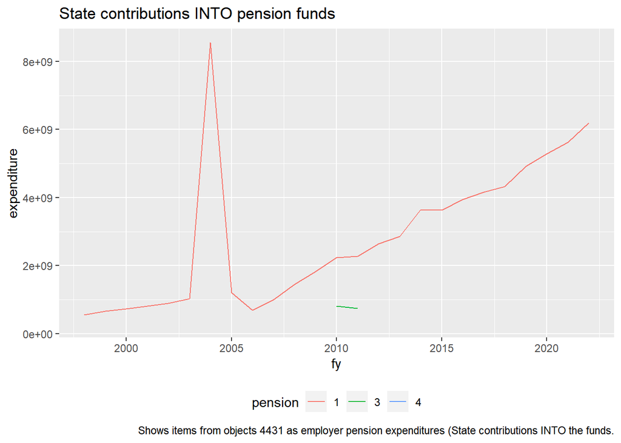

```r
exp_temp %>% filter(pension != 0) %>%
  mutate(pension = as.factor(pension))%>%
  group_by(fy, pension) %>%
  summarize(expenditure = sum(expenditure, na.rm = TRUE)) %>%
  ggplot(aes(x=fy, y = expenditure, group=pension)) +
  geom_line(aes(color = pension)) +

  labs (title = "State contributions INTO pension funds",
  caption = "Shows items from objects 4431 as employer pension expenditures (State contributions INTO the funds.")+
    theme(legend.position = "bottom")
```

```r
# special accounting of pension obligation bond (POB)-funded contributions to JRS, SERS, GARS, TRS

exp_temp <- exp_temp %>%
  # change object for 2010 and 2011, retirement expenditures were bond proceeds and would have been excluded
  mutate(object = ifelse((pension >0 & in_ff == "0"), "4431", object)) %>%
  # changes weird teacher & judge retirement system  pensions object to normal pension object 4431
  mutate(pension =  ifelse(pension >0 & in_ff == "0", 6, pension)) %>% # coded as 6 if it was supposed to be excluded.
  mutate(in_ff = ifelse(pension>0, "1", in_ff))

table(exp_temp$pension)
```

```
##
##      0      1      4      6
## 167723    226      5      8
```

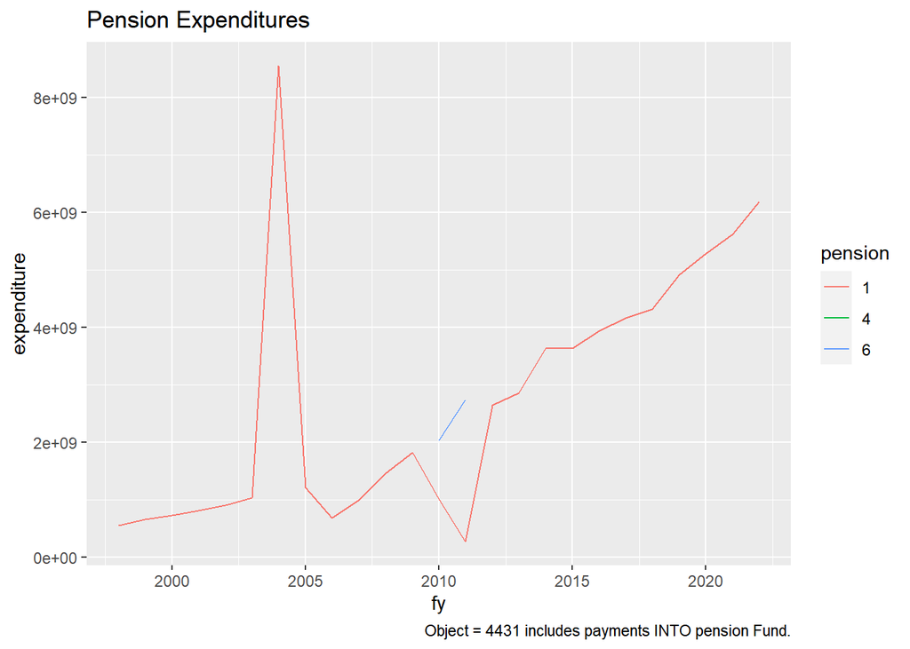

```r
# all other pensions objects  codes get agency code 901 for State Pension Contributions
exp_temp <- exp_temp %>%
  mutate(agency = ifelse(pension>0, "901", as.character(agency)),
         agency_name = ifelse(agency == "901", "State Pension Contributions", as.character(agency_name)))

exp_temp %>%
 filter(pension > 0) %>%
  mutate(pension = as.factor(pension)) %>%
  group_by(fy, pension) %>%
  summarize(expenditure = sum(expenditure, na.rm=TRUE)) %>%
  ggplot(aes(x=fy, y=expenditure, color = pension)) +
  geom_line() +
  labs (title = "Pension Expenditures",
  caption = "Object = 4431 includes payments INTO pension Fund.")
```

### Drop Interfund transfers

```r
transfers_drop <- exp_temp %>% filter(
  agency == "799" | # statutory transfers
           object == "1993" |  # interfund cash transfers
           object == "1298") # purchase of investments

exp_temp <- anti_join(exp_temp, transfers_drop)

#transfers_drop %>% group_by(fy) %>% summarize(expenditure = sum(expenditure)) %>% ggplot(aes(x=fy, y=expenditure)) + geom_line() + labs(title = "Dropped Transfers", caption = "Includes statutory transfers, interfund cash transfers, and purchase of investments")
```

### State employee healthcare costs

State Employee Health Care = Sum of expenditures for “health care coverage as elected by members per state employees group insurance act.” The payments are made from the Health Insurance Reserve Fund. We subtract the share that came from employee contributions. Employee contributions are not considered a revenue source or an expenditure in our analysis.

In FY2013, the Local Government Health Insurance fund was transferred to the department of Central Management Services (agency changes from 478 to 416 in data.)

Employer group insurance contributions for health insurance are excluded to avoid double counting the cost of healthcare. All employer group insurance contributions are coded as object = 1180. BUT the last two fiscal years were coded as 1900 instead of 1180 for lump sums instead of employer contributions  
- anything to do with pandemic money categorization?

Fund = 0457 is “Group insurance premium”, in_ff = 1  
Fund = 0193 is “Local govt health insurance reserve”, in=ff = 0  
fund = 0477 is “Community College Health Insurance”, in=ff = 0.  
- had large amount in early years  
Fund = 0907 = health insurance reserve, in_ff = 1  
Fund = 9939 is “group self-insurers’ insolv”, in_ff = 1  
Fund = 0940 is Self-Insurers security, in_ff = 0  
Fund = 0739 is Group Workers Comp Pool Insol, in_ff = 1

- eehc = 0 means it is NOT a state healthcare cost but it is an employer contribution of some type to some fund
- eehc = 1 means it is a state employee healthcare cost and it is an employer contribution to health insurance

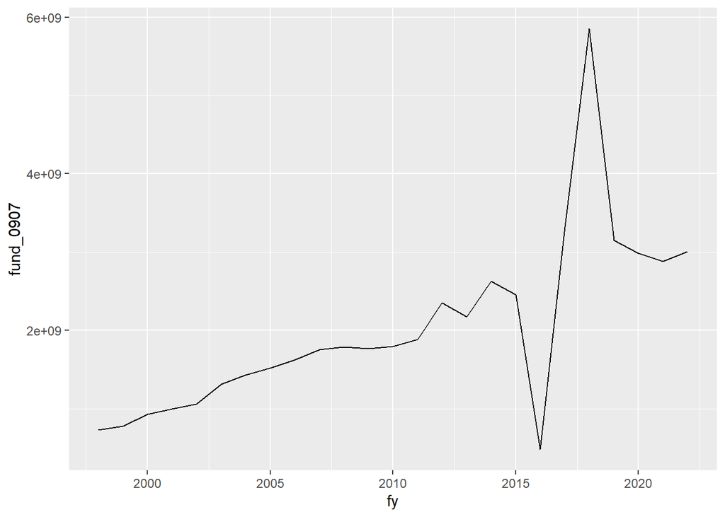

```r
health_ins_reserve <- exp_temp %>% filter(fund == "0907") %>%  group_by(fy) %>%
    summarize(fund_0907 = sum(expenditure,na.rm = TRUE))

health_ins_reserve %>%
  ggplot(aes(x=fy, y=fund_0907)) + geom_line()
```

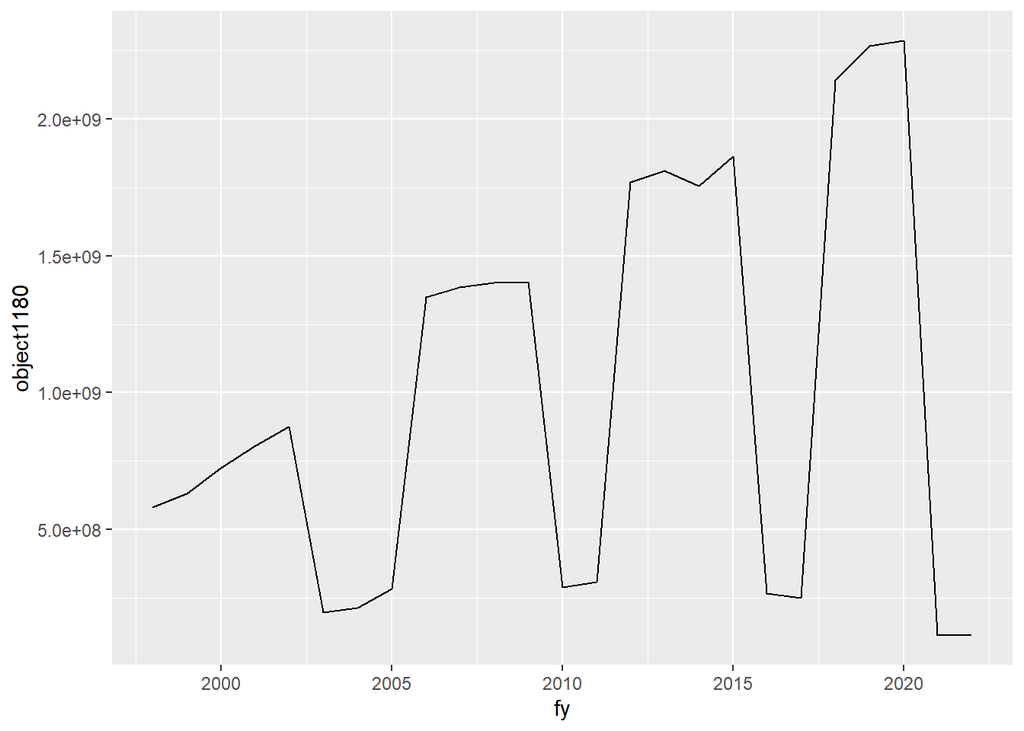

```r
# object 1180 is inconsistently coded over time form the IOC
# object 1180 should be employer contributions to healthcare group insurance
employer_contributions <- exp_temp %>% filter(object == "1180") %>% group_by(fy) %>% summarize(object1180 = sum(expenditure, na.rm = TRUE))

employer_contributions%>%
  ggplot(aes(x=fy, y=object1180)) + geom_line()
```

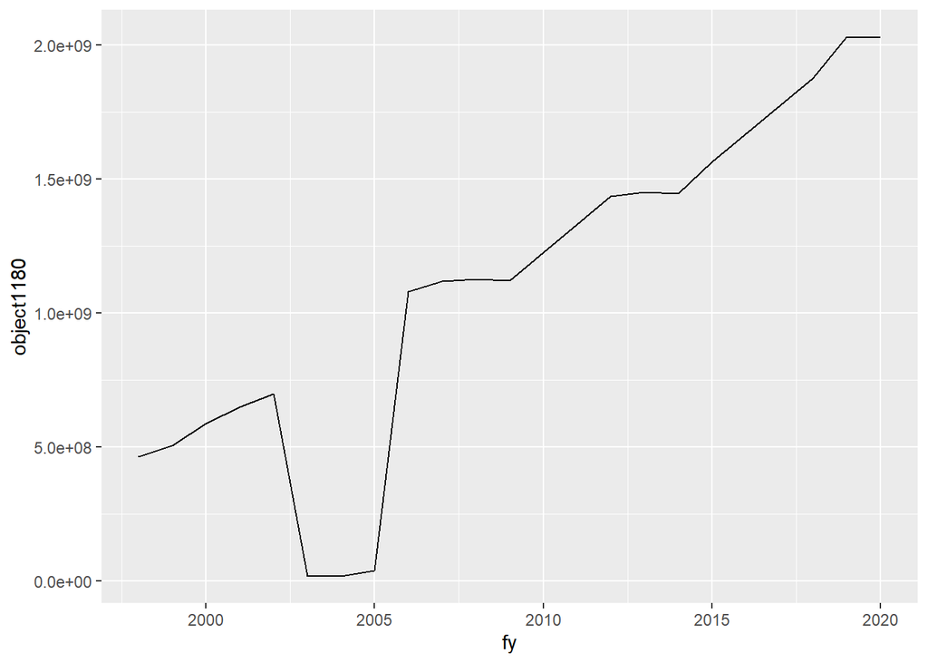

```r
employer_contributions2 <- exp_temp %>% filter(object == "1180" & fund=="0001") %>% group_by(fy) %>% summarize(object1180 = sum(expenditure,na.rm = TRUE))

employer_contributions2 %>%
  ggplot(aes(x=fy, y=object1180)) + geom_line()
```

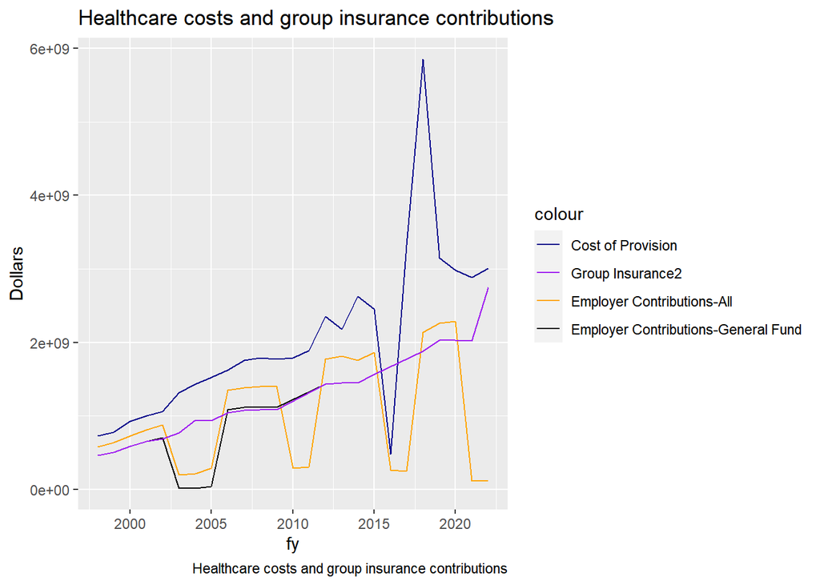

```r
# examine group insurance totals per year
group_ins2 <- exp_temp %>%
  mutate(eehc = ifelse(
    # group insurance contributions for 1998-2005 and 2013-present
    # CMS took over health insurance in 2013
   fund == "0001" & (object == "1180" | object =="1900") & agency == "416" & appr_org=="20", 1, 0) )%>%
  mutate(eehc = ifelse(
    # group insurance contributions for 2006-2012
    # health insurance was in healthcare and family services, agency 478 for a few years
    fund == "0001" & object == "1180" & agency == "478" & appr_org=="80", 1, eehc) )%>%
  filter(eehc == 1) %>%
    group_by(fy) %>%
    summarize(dropped_group_premiums = sum(expenditure, na.rm = TRUE))


# contributions and benefits paid comparison
ggplot()+
  #  geom_line(data=group_ins, aes(x=fy, y=object1180, color='Group Insurance1')) +
    geom_line(data=health_ins_reserve, aes(x=fy, y=fund_0907, color='Cost of Provision')) +
    geom_line(data=employer_contributions, aes(x=fy, y=object1180, color='Employer Contributions-All')) +
    geom_line(data=employer_contributions2, aes(x=fy, y=object1180, color='Employer Contributions-General Fund')) +

  geom_line(data=group_ins2, aes(x=fy, y=dropped_group_premiums, color='Group Insurance2')) +
  #geom_line(data= healthcare_costs, aes(x=fy, y = cost_of_provision, color = 'Healthcare Costs'))+
  scale_color_manual(values = c(
    'Cost of Provision' = 'darkblue',
    'Group Insurance2' = 'purple',
    'Employer Contributions-All' = 'orange',
        'Employer Contributions-General Fund' = 'black'
)) +
  labs(title="Healthcare costs and group insurance contributions",
       caption = "Healthcare costs and group insurance contributions",
       y = "Dollars")
```

```r
exp_temp_check <- exp_temp %>%
  mutate(agency = case_when(   # turns specific items into State Employee Healthcare (agency=904)
      fund=="0907" & (agency=="416" & appr_org=="20") ~ "904",   # central management Bureau of benefits using health insurance reserve
      fund=="0907" & (agency=="478" & appr_org=="80") ~ "904",   # agency = 478: healthcare & family services using health insurance reserve - stopped using this in 2012
    #  fund=="0001" & appr_org=="20" & object=="1900" & agency=="416" & (fy>2002 & fy<2006) ~ "904",

    #  fund=="0001" & appr_org=="20" & object=="1900" & agency=="416" & (fy>2020) ~ "904",

    #  obj_seq_type == "19000000" & wh_approp_name == "GROUP INSURANCE" & (fy>2020) ~ "904",

      TRUE ~ as.character(agency))) %>%

  mutate(agency_name = ifelse(agency == "904", "STATE EMPLOYEE HEALTHCARE", as.character(agency_name)),
         group = ifelse(agency == "904", "904", as.character(agency))) %>% # creates group variable
filter(group == "904") %>% group_by(fy) %>% summarise(healthcare_cost = sum(expenditure))

exp_temp_check
```

| fy | healthcare_cost |
| --- | --- |
| 1998 | 729760549 |
| 1999 | 779017535 |
| 2000 | 927486533 |
| 2001 | 1000125688 |
| 2002 | 1061935688 |
| 2003 | 1314747642 |
| 2004 | 1431565017 |
| 2005 | 1522696601 |
| 2006 | 1622831874 |
| 2007 | 1751623802 |

[output cut: 15 more lines]

```r
# Looks good, Sept 28 AWM
```

If observation is a group insurance contribution, then the expenditure amount is set to $0 (essentially dropped from analysis).

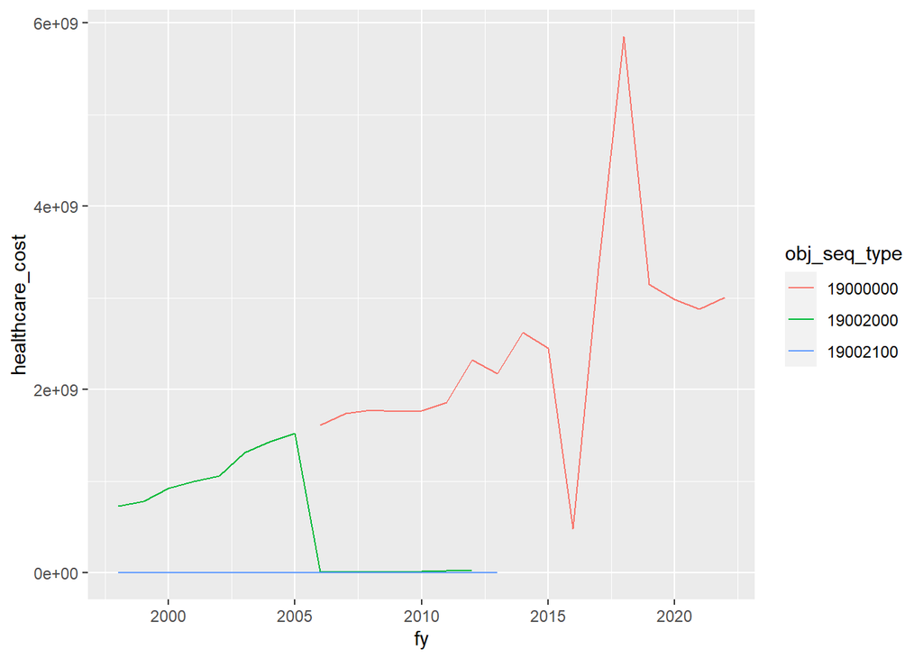

```r
#if observation is a group insurance contribution, then the expenditure amount is set to $0 (essentially dropped from analysis)
exp_temp <- exp_temp %>%
  mutate(eehc = ifelse(
    # group insurance contributions for 1998-2005 and 2013-present
   fund == "0001" & (object == "1180" | object =="1900") & agency == "416" & appr_org=="20", 0, 1) )%>%
  mutate(eehc = ifelse(
    # group insurance contributions for 2006-2012
    fund == "0001" & object == "1180" & agency == "478" & appr_org=="80", 0, eehc) )%>%
     # group insurance contributions from road fund
  # coded with 1900 for some reason??
    mutate(eehc = ifelse(
      fund == "0011" & object == "1900" & agency == "416" & appr_org=="20", 0, eehc) ) %>%

  mutate(expenditure = ifelse(eehc=="0", 0, expenditure)) %>%

  mutate(agency = case_when(   # turns specific items into State Employee Healthcare (agency=904)
      fund=="0907" & (agency=="416" & appr_org=="20") ~ "904",   # central management Bureau of benefits using health insurance reserve
      fund=="0907" & (agency=="478" & appr_org=="80") ~ "904",   # agency = 478: healthcare & family services using health insurance reserve - stopped using this in 2012
      TRUE ~ as.character(agency))) %>%
  mutate(agency_name = ifelse(agency == "904", "STATE EMPLOYEE HEALTHCARE", as.character(agency_name)),
         in_ff = ifelse( agency == "904", 1, in_ff),
         group = ifelse(agency == "904", "904", as.character(agency)))  # creates group variable

# Default group = agency number

healthcare_costs <- exp_temp %>% filter(group == "904")

healthcare_costs %>% group_by(fy,obj_seq_type) %>%
  summarise(healthcare_cost = sum(expenditure, na.rm = TRUE)) %>%
  ggplot() +geom_line(aes(x=fy, y=healthcare_cost, color = obj_seq_type))
```

```r
exp_temp <- anti_join(exp_temp, healthcare_costs) %>% mutate(expenditure = ifelse(object == "1180", 0, expenditure))

healthcare_costs_yearly <- healthcare_costs %>% group_by(fy, group) %>% summarise(healthcare_cost = sum(expenditure, na.rm = TRUE)/1000000) %>% select(-group)
```

> This code chunk above for dealing with group insurance means that healthcare costs need to be added to expenditures after other group names are assigned. Then employee contributions/insurance premiums from the revenue side need to be subtracted from the total cost of employee healthcare for the net cost.

### Local Transfers

Separate transfers to local from parent agencies that come from DOR(492) or Transportation (494). Treats muni revenue transfers as expenditures, not negative revenue.

The share of certain taxes levied state-wide at a common rate and then transferred to local governments. (Purely local-option taxes levied by specific local governments with the state acting as collection agent are NOT included.)

The five corresponding revenue items are:

• Local share of Personal Income Tax  
• Local share of General Sales Tax  
• Personal Property Replacement Tax on Business Income  
• Personal Property Replacement Tax on Public Utilities  
• Local share of Motor Fuel Tax - Transportation Renewal Fund 0952

Notes - these don’t exit: - fund==“0627” & object==“4472”~ “976” # public transportation  
- fund==“0648” & object==“4472” ~ “976”,

```r
exp_temp <- exp_temp %>% mutate(
  agency = case_when(fund=="0515" & object=="4470" & type=="08" ~ "971", # income tax to local governments
                     fund=="0515" & object=="4491" & type=="08" & sequence=="00" ~ "971", # object is shared revenue payments
                     fund=="0802" & object=="4491" ~ "972", #pprt transfer
                     fund=="0515" & object=="4491" & type=="08" & sequence=="01" ~ "976", #gst to local
                     fund=="0627" & object=="4472"~ "976" , # public transportation fund but no observations exist
                     fund=="0648" & object=="4472" ~ "976", # downstate public transportation, but doesn't exist
                     fund=="0515" & object=="4470" & type=="00" ~ "976", # object 4470 is grants to local governments
                    object=="4491" & (fund=="0188"|fund=="0189") ~ "976",
                     fund=="0187" & object=="4470" ~ "976",
                     fund=="0186" & object=="4470" ~ "976",
                    object=="4491" & (fund=="0413"|fund=="0414"|fund=="0415")  ~ "975", #mft to local
                  fund == "0952"~ "975", # Added Sept 29 2022 AWM. Transportation Renewal MFT
                    TRUE ~ as.character(agency)),

  agency_name = case_when(agency == "971"~ "INCOME TAX 1/10 TO LOCAL",
                          agency == "972" ~ "PPRT TRANSFER TO LOCAL",
                          agency == "975" ~ "MFT TO LOCAL",
                          agency == "976" ~ "GST TO LOCAL",
                          TRUE~as.character(agency_name)),
  group = ifelse(agency>"970" & agency < "977", as.character(agency), as.character(group)))
```

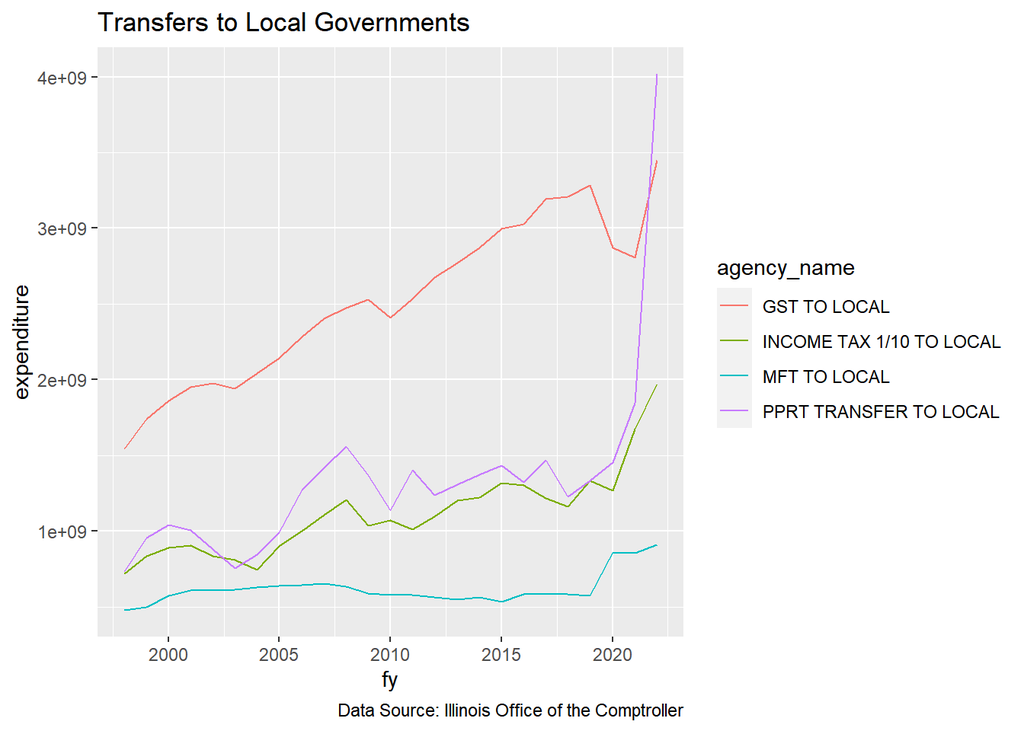

```r
transfers_long <- exp_temp %>%
  filter(group == "971" |group == "972" | group == "975" | group == "976")

transfers_long %>%
  group_by(agency_name, group, fy) %>%
  summarize(expenditure = sum(expenditure, na.rm=TRUE) )%>%
  ggplot() + geom_line(aes(x=fy, y = expenditure, color=agency_name)) + labs(title = "Transfers to Local Governments", caption = "Data Source: Illinois Office of the Comptroller")
```

```r
transfers <- transfers_long %>%
  group_by(fy, group ) %>%
  summarize(sum_expenditure = sum(expenditure)/1000000) %>%
  pivot_wider(names_from = "group", values_from = "sum_expenditure", names_prefix = "exp_" )

exp_temp <- anti_join(exp_temp, transfers_long)


dropped_inff_0 <- exp_temp %>% filter(in_ff == 0)

exp_temp <- exp_temp %>% filter(in_ff == 1) # drops in_ff = 0 funds AFTER dealing with net-revenue above
```

### Debt Service

Debt Service expenditures include interest payment on both short-term and long-term debt. We do not include escrow or principal payments.

**Decision from Sept 30 2022:** We are no longer including short term principal payments as a cost; only interest on borrowing is a cost. Pre FY22 and the FY21 correction, we did include an escrow payment and principle payments as costs but not bond proceeds as revenues. This caused expenditures to be inflated because we were essentially counting debt twice - the principle payment and whatever the money was spent on in other expenditure categories, which was incorrect.

```r
debt_drop <- exp_temp %>%
  filter(object == "8841" |  object == "8811")
# escrow  OR  principle

#debt_drop %>% group_by(fy) %>% summarize(sum = sum(expenditure)) %>% arrange(-fy)


debt_keep <- exp_temp %>%
  filter(fund != "0455" & (object == "8813" | object == "8800" ))
# examine the debt costs we want to include

#debt_keep %>% group_by(fy) %>% summarize(sum = sum(expenditure)) %>% arrange(-fy)


exp_temp <- anti_join(exp_temp, debt_drop)
exp_temp <- anti_join(exp_temp, debt_keep)

debt_keep <- debt_keep %>%
  mutate(
    agency = ifelse(fund != "0455" & (object == "8813" | object == "8800"), "903", as.character(agency)),
    group = ifelse(fund != "0455" & (object == "8813" | object == "8800"), "903", as.character(group)),
    in_ff = ifelse(group == "903", 1, as.character(in_ff)))

debt_keep_yearly <- debt_keep %>% group_by(fy, group) %>% summarize(debt_cost = sum(expenditure,na.rm=TRUE)/1000000) %>% select(-group)
```

### Medicaid

**Medicaid.** That portion of the Healthcare and Family Services (or Public Aid in earlier years, agency code 478) budget for Medical (appr_organization code 65) for awards and grants (object codes 4400 and 4900).

> State CURE will remain in the Medicaid expenditure category due to the nature of it being federal funds providing public health services and funding to locations that provide public services.
- Uses same appropriation name of “HEALTHCARE PROVIDER RELIEF” and fund == 0793 and obj_seq_type == 49000000. So can defend the “mistake” of including healthcare provider relief as Medicaid expenditure.

## Add Other Fiscal Future group codes

```r
exp_temp <- exp_temp %>%
  #mutate(agency = as.numeric(agency) ) %>%
  # arrange(agency)%>%
  mutate(
    group = case_when(
      agency>"100"& agency<"200" ~ "910", # legislative

      agency == "528"  | (agency>"200" & agency<"300") ~ "920", # judicial
      pension>0  ~ "901", # pensions
      (agency>"309" & agency<"400") ~ "930",    # elected officers

      agency == "586" ~ "959", # create new K-12 group

      agency=="402" | agency=="418" | agency=="478" | agency=="444" | agency=="482" ~ as.character(agency), # aging, CFS, HFS, human services, public health
      T ~ as.character(group))
    ) %>%


  mutate(group = case_when(
    agency=="478" & (appr_org=="01" | appr_org == "65" | appr_org=="88") & (object=="4900" | object=="4400") ~ "945", # separates CHIP from health and human services and saves it as Medicaid

    agency == "586" & fund == "0355" ~ "945",  # 586 (Board of Edu) has special education which is part of medicaid

    # OLD CODE: agency == "586" & appr_org == "18" ~ "945", # Spec. Edu Medicaid Matching

    agency=="425" | agency=="466" | agency=="546" | agency=="569" | agency=="578" | agency=="583" | agency=="591" | agency=="592" | agency=="493" | agency=="588" ~ "941", # public safety & Corrections

    agency=="420" | agency=="494" |  agency=="406" | agency=="557" ~ as.character(agency), # econ devt & infra, tollway

    agency=="511" | agency=="554" | agency=="574" | agency=="598" ~ "946",  # Capital improvement

    agency=="422" | agency=="532" ~ as.character(agency), # environment & nat. resources

    agency=="440" | agency=="446" | agency=="524" | agency=="563"  ~ "944", # business regulation

    agency=="492" ~ "492", # revenue

    agency == "416" ~ "416", # central management services
    agency=="448" & fy > 2016 ~ "416", #add DoIT to central management

    T ~ as.character(group))) %>%


  mutate(group = case_when(
    # agency=="684" | agency=="691"  ~ as.character(agency), # moved under higher reducation in next line. 11/28/2022 AWM

    agency=="692" | agency=="695" | agency == "684" |agency == "691" | (agency>"599" & agency<"677") ~ "960", # higher education

    agency=="427"  ~ as.character(agency), # employment security

    agency=="507"|  agency=="442" | agency=="445" | agency=="452" |agency=="458" | agency=="497" ~ "948", # other departments

    # other boards & Commissions
    agency=="503" | agency=="509" | agency=="510" | agency=="565" |agency=="517" | agency=="525" | agency=="526" | agency=="529" | agency=="537" | agency=="541" | agency=="542" | agency=="548" |  agency=="555" | agency=="558" | agency=="559" | agency=="562" | agency=="564" | agency=="568" | agency=="579" | agency=="580" | agency=="587" | agency=="590" | agency=="527" | agency=="585" | agency=="567" | agency=="571" | agency=="575" | agency=="540" | agency=="576" | agency=="564" | agency=="534" | agency=="520" | agency=="506" | agency == "533" ~ "949",

    # non-pension expenditures of retirement funds moved to "Other Departments"
    # should have removed pension expenditures already from exp_temp in Pensions step above
    agency=="131" | agency=="275" | agency=="589" |agency=="593"|agency=="594"|agency=="693" ~ "948",

    T ~ as.character(group))) %>%

  mutate(group_name =
           case_when(
             group == "416" ~ "Central Management",
             group == "478" ~ "Healthcare and Family Services",
             group == "482" ~ "Public Health",
             group == "900" ~ "NOT IN FRAME",
             group == "901" ~ "STATE PENSION CONTRIBUTION",
             group == "903" ~ "DEBT SERVICE",
             group == "910" ~ "LEGISLATIVE"  ,
             group == "920" ~ "JUDICIAL" ,
             group == "930" ~ "ELECTED OFFICERS" ,
             group == "940" ~ "OTHER HEALTH-RELATED",
             group == "941" ~ "PUBLIC SAFETY" ,
             group == "942" ~ "ECON DEVT & INFRASTRUCTURE" ,
             group == "943" ~ "CENTRAL SERVICES",
             group == "944" ~ "BUS & PROFESSION REGULATION" ,
             group == "945" ~ "MEDICAID" ,
             group == "946" ~ "CAPITAL IMPROVEMENT" ,
             group == "948" ~ "OTHER DEPARTMENTS" ,
             group == "949" ~ "OTHER BOARDS & COMMISSIONS" ,
             group == "959" ~ "K-12 EDUCATION" ,
             group == "960" ~ "UNIVERSITY EDUCATION" ,
             group == agency ~ as.character(group),
             TRUE ~ "Check name"),
         year = fy)

exp_temp %>% filter(group_name == "Check name")
```

| fy | fund | fund_name | agency | agency_name | appr_org | org_name | obj_seq_type | appn_net_xfer | expenditure | data_source | object | category | sequence | type | trans_agency | trans_type | wh_approp_name | fund_cat | fund_cat_name.x | expenditurethrough6302022 | fund_ab | fund_ioc | fund_re | a_end | in_ff | fund_name_ab | fund_category | fund_cat_name.y | in_ff_rev | … |
| --- | --- | --- | --- | --- | --- | --- | --- | --- | --- | --- | --- | --- | --- | --- | --- | --- | --- | --- | --- | --- | --- | --- | --- | --- | --- | --- | --- | --- | --- | --- |

```r
#write_csv(exp_temp, "all_expenditures_recoded.csv")
```

All expenditures recoded but not aggregated: Allows for inspection of individual expenditures within larger categories. This stage of the data is extremely useful for investigating almost all questions we have about the data.

Note that these are the raw figures BEFORE we take the additional steps:

- Subtract employee insurance premiums from State Employee Healthcare expenditures
- Subtract tax refunds from tax revenues by revenue type.

## Modify Revenue data

Revenue Categories NOT included in Fiscal Futures:  
- 32. Garnishment-Levies. (State is fiduciary, not beneficiary.)  
- 45. Student Fees-Universities. (Excluded from state-level budget.)  
- 51. Retirement Contributions (of individuals and non-state entities).  
- 66. Proceeds, Investment Maturities. (Not sustainable flow.)  
- 72. Bond Issue Proceeds. (Not sustainable flow.)  
- 75. Inter-Agency Receipts.  
- 79. Cook County Intergovernmental Transfers. (State is not beneficiary.)  
- 98. Prior Year Refunds.  
- 99. Statutory Transfers.

**All Other Sources**

Expanded to include the following smaller sources:  
- 30. Horse Racing Taxes & Fees.  
- 60. Other Grants and Contracts.  
- 63. Investment Income.

For aggregating revenue, use the rev_1998_2022 dataframe, join the funds_ab_in_2022 file to it, and then join the ioc_source_type file to the dataset. Remember: You need to update the funds_ab_in and ioc_source_type file every year!

```r
# fund info to revenue for all years
rev_temp <- inner_join(rev_1998_2022, funds_ab_in_2022, by = "fund") %>% arrange(source)

# need to update the ioc_source_type file every year!
ioc_source_type <- readxl::read_xlsx("C:/Users/aleaw/OneDrive/Documents/PhD Fall 2021 - Spring 2022/Merriman RA/Fiscal Futures FY2022/Replication-Files/ioc_source_updated22_AWM.xlsx")

rev_temp <- left_join(rev_temp, ioc_source_type, by = "source")
# automatically used source, source name does not match for the join to work using source_name



# recodes old agency numbers to consistent agency number
rev_temp <- rev_temp %>%
  mutate(agency = case_when(
    (agency=="438"| agency=="475" |agency == "505") ~ "440",
    # financial institution &  professional regulation &
     # banks and real estate  --> coded as  financial and professional reg
    agency == "473" ~ "588", # nuclear safety moved into IEMA
    (agency =="531" | agency =="577") ~ "532", # coded as EPA
    (agency =="556" | agency == "538") ~ "406", # coded as agriculture
    agency == "560" ~ "592", # IL finance authority (fire trucks and agriculture stuff)to state fire marshal
    agency == "570" & fund == "0011" ~ "494",   # city of Chicago road fund to transportation
    TRUE ~ (as.character(agency))))
```

### Federal to State Transfers

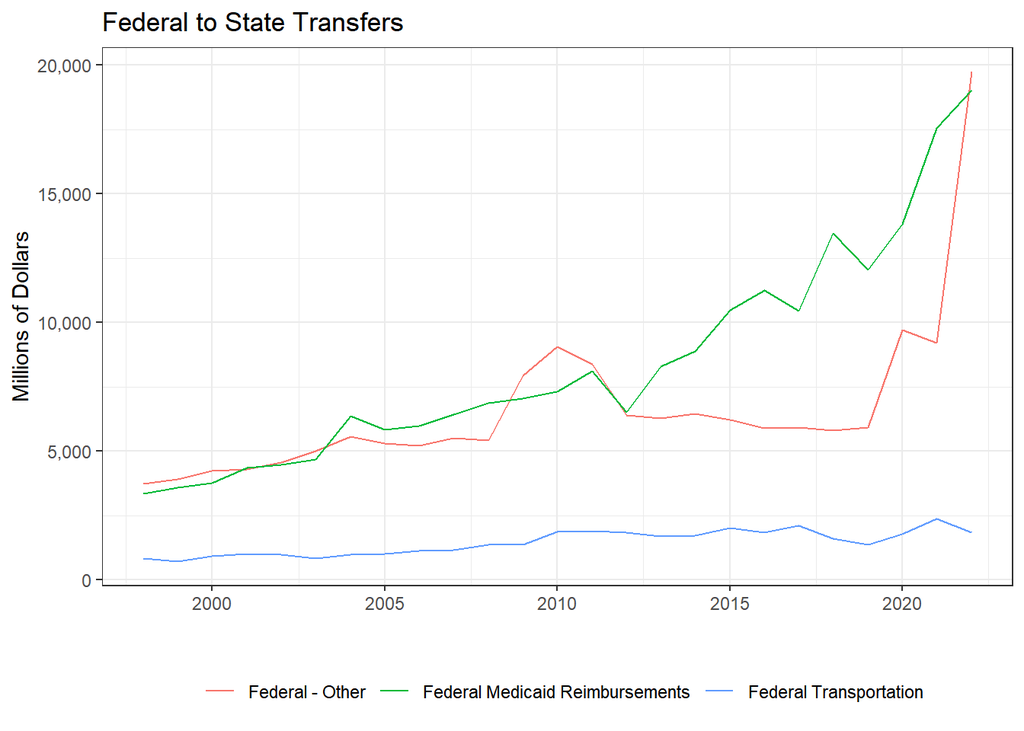

```r
rev_temp <- rev_temp %>% filter(in_ff==1)

rev_temp <- rev_temp %>%
  mutate(
    rev_type = ifelse(rev_type=="57" & agency=="478" & (source=="0618"|source=="2364"|source=="0660"|source=="1552"| source=="2306"| source=="2076"|source=="0676"|source=="0692"), "58", rev_type),
    rev_type_name = ifelse(rev_type=="58", "Federal Medicaid Reimbursements", rev_type_name),
    rev_type = ifelse(rev_type=="57" & agency=="494", "59", rev_type),
    rev_type_name = ifelse(rev_type=="59", "Federal Transportation", rev_type_name),
    rev_type_name = ifelse(rev_type=="57", "Federal - Other", rev_type_name),
    rev_type = ifelse(rev_type=="6", "06", rev_type),
    rev_type = ifelse(rev_type=="9", "09", rev_type))

rev_temp %>%
  filter(rev_type == "58" | rev_type == "59" | rev_type == "57") %>%
  group_by(fy, rev_type, rev_type_name) %>%
  summarise(receipts = sum(receipts, na.rm = TRUE)/1000000) %>%
  ggplot() +
  geom_line(aes(x=fy, y=receipts,color=rev_type_name)) +
      theme_bw() +
  scale_y_continuous(labels = comma)+
  labs(title = "Federal to State Transfers",
       y = "Millions of Dollars", x = "") +
  theme(legend.position = "bottom", legend.title = element_blank()  )
```

Looking at Federal Revenue:

```r
rev_temp %>% filter(rev_type == "57" & fy == 2021) %>% group_by(source_name_AWM) %>% summarize(receipts =sum(receipts)) %>% arrange(-receipts)
```

| source_name_AWM | receipts |
| --- | --- |
| DEPARTMENT OF EDUCATION-FED | 2.467118e+09 |
| HEALTH AND HUMAN SERVICES | 9.924245e+08 |
| AGRICULTURE, DEPARTMENT OF | 9.634642e+08 |
| FEMA | 8.470389e+08 |
| TREASURY, DEPARTMENT OF | 5.663960e+08 |
| FED MONIES - TANF GRANT | 5.189545e+08 |
| MEDICAL ADMINISTRATION | 4.553137e+08 |
| LABOR,DEPARTMENT OF | 4.445515e+08 |
| CCDBG MANDATORY DISC | 3.960949e+08 |
| HHS FEDERAL BLOCK GRANT | 3.488437e+08 |

[output cut: 77 more lines]

```r
rev_temp %>% filter(rev_type == "57" & fy == 2021 & source_name_AWM == "FEDERAL STIMULUS PACKAGE") %>% group_by(fund_name) %>% summarize(receipts =sum(receipts)) %>% arrange(-receipts)
```

| fund_name | receipts |
| --- | --- |
| STATE CURE | 228414389 |

```r
exp_temp %>% filter(fy == 2022 & (fund_name == "STATE CURE" | fund_name == "LOCAL CURE")) %>% group_by(org_name, agency_name, wh_approp_name, fund_name) %>% summarize(sum=sum(expenditure)) %>% arrange(-sum)
```

| org_name | agency_name | wh_approp_name | fund_name | sum |
| --- | --- | --- | --- | --- |
| GOVERNMENT SERVICES | REVENUE | LOC GOVT ARPA | LOCAL CURE | 371089695.50 |
| BUSINESS DEVELOPMENT | COMMERCE AND ECONOMIC OPPORTUN | COSTS BACK TO BSNESS GRNT PRGM | STATE CURE | 251265296.42 |
| MEDICAL | HEALTHCARE & FAMILY SERVICES | SUPPORT TO ILLINOIS HOSPITALS | STATE CURE | 174879953.42 |
| MNGMNT/ADMINISTRATIVE SUPPORT | IL EMERGENCY MANAGEMENT AGCY | OPER EXP, AWARDS AND GRANTS | STATE CURE | 114811190.57 |
| GOVERNMENT SERVICES | REVENUE | GRANTS AND ADMIN EXP | STATE CURE | 73605983.00 |
| MEDICAL | HEALTHCARE & FAMILY SERVICES | LONG TERM CARE SERVICES PRGMS | STATE CURE | 73499374.49 |
| MEDICAL | HEALTHCARE & FAMILY SERVICES | COVID LONG TERM CARE SERVICES | STATE CURE | 45023436.45 |
| LEGISLATIVE INITIATIVES | HUMAN SERVICES | GRNTS AND ADMIN EXPENSES | STATE CURE | 38197830.88 |
| OFFICE OF HEALTH PROTECTION | PUBLIC HEALTH | OPER AND CONTINGENT EXP | STATE CURE | 37700000.00 |
| MEDICAL | HEALTHCARE & FAMILY SERVICES | GRNT TO ANN & RBRT H LRIE HOSP | STATE CURE | 20000000.00 |

[output cut: 30 more lines]

```r
exp_temp %>% filter(fy == 2022 & (fund_name == "STATE CURE" | fund_name == "LOCAL CURE")) %>% group_by(org_name, agency_name, object, wh_approp_name, fund_name) %>% summarize(sum=sum(expenditure)) %>% arrange(-sum)
```

| org_name | agency_name | object | wh_approp_name | fund_name | sum |
| --- | --- | --- | --- | --- | --- |
| GOVERNMENT SERVICES | REVENUE | 4491 | LOC GOVT ARPA | LOCAL CURE | 371089695.50 |
| BUSINESS DEVELOPMENT | COMMERCE AND ECONOMIC OPPORTUN | 4900 | COSTS BACK TO BSNESS GRNT PRGM | STATE CURE | 251265296.42 |
| MEDICAL | HEALTHCARE & FAMILY SERVICES | 4900 | SUPPORT TO ILLINOIS HOSPITALS | STATE CURE | 174879953.42 |
| MNGMNT/ADMINISTRATIVE SUPPORT | IL EMERGENCY MANAGEMENT AGCY | 4900 | OPER EXP, AWARDS AND GRANTS | STATE CURE | 114811190.57 |
| GOVERNMENT SERVICES | REVENUE | 4900 | GRANTS AND ADMIN EXP | STATE CURE | 73605983.00 |
| MEDICAL | HEALTHCARE & FAMILY SERVICES | 4900 | LONG TERM CARE SERVICES PRGMS | STATE CURE | 73499374.49 |
| MEDICAL | HEALTHCARE & FAMILY SERVICES | 4900 | COVID LONG TERM CARE SERVICES | STATE CURE | 45023436.45 |
| LEGISLATIVE INITIATIVES | HUMAN SERVICES | 4900 | GRNTS AND ADMIN EXPENSES | STATE CURE | 38197830.88 |
| OFFICE OF HEALTH PROTECTION | PUBLIC HEALTH | 4400 | OPER AND CONTINGENT EXP | STATE CURE | 37700000.00 |
| MEDICAL | HEALTHCARE & FAMILY SERVICES | 4400 | GRNT TO ANN & RBRT H LRIE HOSP | STATE CURE | 20000000.00 |

[output cut: 30 more lines]

```r
exp_temp %>% filter(fy == 2022 & (fund_name == "STATE CURE" | fund_name == "LOCAL CURE")) %>% group_by(agency_name, object, wh_approp_name, fund_name) %>% summarize(sum=sum(expenditure)) %>% arrange(-sum)
```

| agency_name | object | wh_approp_name | fund_name | sum |
| --- | --- | --- | --- | --- |
| REVENUE | 4491 | LOC GOVT ARPA | LOCAL CURE | 371089695.50 |
| COMMERCE AND ECONOMIC OPPORTUN | 4900 | COSTS BACK TO BSNESS GRNT PRGM | STATE CURE | 251265296.42 |
| HEALTHCARE & FAMILY SERVICES | 4900 | SUPPORT TO ILLINOIS HOSPITALS | STATE CURE | 174879953.42 |
| IL EMERGENCY MANAGEMENT AGCY | 4900 | OPER EXP, AWARDS AND GRANTS | STATE CURE | 114811190.57 |
| REVENUE | 4900 | GRANTS AND ADMIN EXP | STATE CURE | 73605983.00 |
| HEALTHCARE & FAMILY SERVICES | 4900 | LONG TERM CARE SERVICES PRGMS | STATE CURE | 73499374.49 |
| HEALTHCARE & FAMILY SERVICES | 4900 | COVID LONG TERM CARE SERVICES | STATE CURE | 45023436.45 |
| HUMAN SERVICES | 4900 | GRNTS AND ADMIN EXPENSES | STATE CURE | 38197830.88 |
| PUBLIC HEALTH | 4400 | OPER AND CONTINGENT EXP | STATE CURE | 37700000.00 |
| HEALTHCARE & FAMILY SERVICES | 4400 | GRNT TO ANN & RBRT H LRIE HOSP | STATE CURE | 20000000.00 |

[output cut: 30 more lines]

```r
exp_temp %>% filter(fy == 2022 & (fund_name == "STATE CURE" | fund_name == "LOCAL CURE")) %>% group_by(fund_name, object, org_name) %>% summarize(sum=sum(expenditure)) %>% arrange(-sum)
```

| fund_name | object | org_name | sum |
| --- | --- | --- | --- |
| LOCAL CURE | 4491 | GOVERNMENT SERVICES | 371089695.50 |
| STATE CURE | 4900 | MEDICAL | 310017600.83 |
| STATE CURE | 4900 | BUSINESS DEVELOPMENT | 258346934.14 |
| STATE CURE | 4900 | MNGMNT/ADMINISTRATIVE SUPPORT | 114811190.57 |
| STATE CURE | 4900 | GOVERNMENT SERVICES | 73605983.00 |
| STATE CURE | 4900 | LEGISLATIVE INITIATIVES | 54662371.92 |
| STATE CURE | 4400 | OFFICE OF HEALTH PROTECTION | 37700000.00 |
| STATE CURE | 4400 | MEDICAL | 20000000.00 |
| LOCAL CURE | 4900 | COMMUNITY DEVELOPMENT | 18966047.61 |
| STATE CURE | 4400 | LEGISLATIVE INITIATIVES | 5702332.45 |

[output cut: 13 more lines]

```r
exp_temp %>% filter(fy == 2022 & (fund_name == "STATE CURE" | fund_name == "LOCAL CURE")) %>% group_by(fund_name, agency_name) %>% summarize(sum=sum(expenditure)) %>% arrange(-sum)
```

| fund_name | agency_name | sum |
| --- | --- | --- |
| LOCAL CURE | REVENUE | 371089695.50 |
| STATE CURE | HEALTHCARE & FAMILY SERVICES | 330017600.83 |
| STATE CURE | COMMERCE AND ECONOMIC OPPORTUN | 262335067.82 |
| STATE CURE | IL EMERGENCY MANAGEMENT AGCY | 114829894.78 |
| STATE CURE | REVENUE | 73605983.00 |
| STATE CURE | HUMAN SERVICES | 60364704.37 |
| STATE CURE | PUBLIC HEALTH | 40700000.00 |
| LOCAL CURE | COMMERCE AND ECONOMIC OPPORTUN | 18966047.61 |
| STATE CURE | CHILDREN AND FAMILY SERVICES | 833333.30 |
| STATE CURE | IL CRIMINAL JUSTICE INFO AUTH | 691196.33 |

[output cut: 4 more lines]

```r
exp_temp %>% filter(fy == 2022 & (fund_name == "STATE CURE" | fund_name == "LOCAL CURE")) %>% group_by(agency_name) %>% summarize(sum=sum(expenditure)) %>% arrange(-sum)
```

| agency_name | sum |
| --- | --- |
| REVENUE | 444695678.50 |
| HEALTHCARE & FAMILY SERVICES | 330017600.83 |
| COMMERCE AND ECONOMIC OPPORTUN | 281301115.43 |
| IL EMERGENCY MANAGEMENT AGCY | 114829894.78 |
| HUMAN SERVICES | 60364704.37 |
| PUBLIC HEALTH | 40700000.00 |
| CHILDREN AND FAMILY SERVICES | 833333.30 |
| IL CRIMINAL JUSTICE INFO AUTH | 691196.33 |
| IL ARTS COUNCIL | 583000.00 |
| IL STUDENT ASSISTANCE COMM | 422851.76 |

[output cut: 2 more lines]

```r
exp_temp %>% filter(fy == 2021 & (fund_name == "STATE CURE" | fund_name == "LOCAL CURE")) %>% group_by(wh_approp_name, fund_name) %>% summarize(sum=sum(expenditure)) %>% arrange(-sum)
```

| wh_approp_name | fund_name | sum |
| --- | --- | --- |
| COVID LONG TERM CARE SERVICES | STATE CURE | 342893715.4 |
| CORONA BUS INTRUPTN GRNT PROG | STATE CURE | 319800000.0 |
| CORONA BUS INTRUPTNGRNT PROG | STATE CURE | 261795225.9 |
| COVID AFFRDABL HOUSING GRANTS | STATE CURE | 236778933.0 |
| COVID19 GRANTS AND EXP REIMBUR | LOCAL CURE | 220822682.2 |
| COVD AMBULNC & MED ASST PROVDS | STATE CURE | 181120502.1 |
| CORONAVIRUS RELIEF | STATE CURE | 132171934.9 |
| COVID FED QUAL HEALTH CENTERS | STATE CURE | 112629882.6 |
| COVID ADDRDABL HOUSING GRANTS | STATE CURE | 100000000.0 |
| COVD SPCLZD MENTL HLTH REHAB | STATE CURE | 11752532.0 |

[output cut: 1 more lines]

### Health Insurance Premiums from Employees

0120 = ins prem-option life 0120 = ins prem-optional life/univ

0347 = optional health - HMO 0348 = optional health - dental 0349 = optional health - univ/local SI 0350 = optional health - univ/local 0351 = optional health - retirement 0352 = optional health - retirement SI 0353 = optional health - retire/dental 0354 = optional health - retirement hmo

2199-2209 = various HMOs, dental, health plans from Health Insurance Reserve (fund)

```r
#collect optional insurance premiums to fund 0907 for use in eehc expenditure
rev_temp <- rev_temp %>%
  mutate(employee_premiums = ifelse(
    fund=="0907" & (source=="0120"| source=="0121"| (source>"0345" & source<"0357")|(source>"2199" & source<"2209")), 1, 0),

    # adds more rev_type codes
    rev_type = case_when(
      fund =="0427" ~ "12", # pub utility tax
      fund == "0742" | fund == "0473" ~ "24", # insurance and fees
      fund == "0976" ~ "36",# receipts from rev producing
      fund == "0392" |fund == "0723" ~ "39", # licenses and fees
      fund == "0656" ~ "78", #all other rev sources
      TRUE ~ as.character(rev_type)))
# if not mentioned, then rev_type as it was



# # optional insurance premiums = employee insurance premiums
# emp_premium <- rev_temp %>%
#   group_by(fy, employee_premiums) %>%
#   summarize(employee_premiums_sum = sum(receipts)/1000000) %>%
#   filter(employee_premiums == 1) %>%
#   rename(year = fy) %>%
#   select(-employee_premiums)

emp_premium_long <- rev_temp %>%  filter(employee_premiums == 1)
# 381 observations have employee premiums == 1


# drops employee premiums from revenue
rev_temp <- rev_temp %>% filter(employee_premiums != 1)
```

Employee premiums on the revenue side should have receipts coded as $0 or be dropped using anti_join().

### Transfers in and Out:

**I don’t have much faith in the transfers in and out steps- AWM**

- in_from_out <- c(“0847”, “0867”, “1175”, “1176”, “1177”, “1178”, “1181”, “1182”, “1582”, “1592”, “1745”, “1982”, “2174”, “2264”)
- See the methodology document for the list of what these sources/funds are.

```r
rev_temp <- rev_temp %>%
  filter(in_ff == 1) %>%
  mutate(local = ifelse(is.na(local), 0, local)) %>% # drops all revenue observations that were coded as "local == 1"
  filter(local != 1)

# 1175 doesnt exist?
in_from_out <- c("0847", "0867", "1175", "1176", "1177", "1178", "1181", "1182", "1582", "1592", "1745", "1982", "2174", "2264")

# what does this actually include:
# all are items with rev_type = 75 originally.
in_out_df <- rev_temp %>%
  mutate(infromout = ifelse(source %in% in_from_out, 1, 0)) %>%
  filter(infromout == 1)

rev_temp <- rev_temp %>%
  mutate(rev_type_new = ifelse(source %in% in_from_out, "76", rev_type))
# if source contains any of the codes in in_from_out, code them as 76 (all other rev).
```

```r
# revenue types to drop
drop_type <- c("32", "45", "51",
               "66", "72", "75", "79", "98")

# drops Blank, Student Fees, Retirement contributions, proceeds/investments,
# bond issue proceeds, interagency receipts, cook IGT, Prior year refunds.


rev_temp <- rev_temp %>% filter(!rev_type_new %in% drop_type)
# keep observations that do not have a revenue type mentioned in drop_type

table(rev_temp$rev_type_new)
```

```
##
##    02    03    06    09    12    15    18    21    24    27    30    31    33
##   161   124   828   127   575   258    45  1420   450    76   659   124   130
##    35    36    39    42    48    54    57    58    59    60    63    76    78
##   660  5152  9044  2755    31  1239  6451   620   226   103  5081   154 10880
##    99
##   964
```

```r
rev_temp %>%
  group_by(fy, rev_type_new) %>%
  summarize(total_reciepts = sum(receipts)/1000000) %>%
  pivot_wider(names_from = rev_type_new, values_from = total_reciepts, names_prefix = "rev_")
```

| fy | rev_02 | rev_03 | rev_06 | rev_09 | rev_12 | rev_15 | rev_18 | rev_21 | rev_24 | rev_27 | rev_30 | rev_31 | rev_33 | rev_35 | rev_36 | rev_39 | rev_42 | rev_48 | rev_54 | rev_57 | rev_58 | rev_59 | rev_60 | rev_63 | rev_76 | rev_78 | rev_99 | rev_NA |
| --- | --- | --- | --- | --- | --- | --- | --- | --- | --- | --- | --- | --- | --- | --- | --- | --- | --- | --- | --- | --- | --- | --- | --- | --- | --- | --- | --- | --- |
| 1998 | 6846.827 | 1860.322 | 7198.401 | 1300.658 | 1193.328 | 464.2421 | 57.03395 | 250.4342 | 132.3373 | 122.7717 | 42.827602 | 543.1538 | 834.6949 | 244.6849 | 727.7252 | 304.8013 | 747.4372 | 210.4965 | 138.1076 | 3747.793 | 3339.059 | 835.1585 | 2.73917896 | 277.61175 | 59.54166 | 486.6153 | NA | NA |
| 1999 | 7225.764 | 1854.888 | 7646.728 | 1328.799 | 1423.402 | 499.0560 | 57.23468 | 346.9777 | 248.5650 | 121.3476 | 41.640032 | 548.5763 | 844.8850 | 268.8884 | 715.9857 | 328.4494 | 773.0030 | 309.8295 | 157.9744 | 3924.452 | 3599.680 | 725.9854 | 2.53047152 | 306.53295 | 73.16676 | 535.8230 | NA | NA |
| 2000 | 7685.811 | 2067.907 | 8218.148 | 1356.283 | 1524.369 | 467.3495 | 127.86824 | 348.0088 | 267.6100 | 143.9242 | 22.584853 | 649.1760 | 814.2806 | 275.4470 | 736.8125 | 402.6987 | 973.4303 | 435.9784 | 180.3469 | 4232.726 | 3763.416 | 927.4700 | 2.91999703 | 349.50797 | 70.72210 | 945.1123 | NA | NA |
| 2001 | 7995.794 | 1789.672 | 8175.164 | 1366.563 | 1605.878 | 472.6152 | 124.31482 | 361.0388 | 298.2466 | 150.6893 | 12.826824 | 678.1501 | 765.0459 | 281.5546 | 743.0530 | 526.6566 | 1134.5203 | 490.7099 | 202.9800 | 4309.878 | 4355.735 | 1019.2127 | 3.08349373 | 425.44721 | 68.16008 | 847.1489 | NA | NA |
| 2002 | 7471.385 | 1383.822 | 8279.112 | 1373.522 | 1568.098 | 468.7761 | 122.00049 | 329.1675 | 322.8413 | 165.3039 | 12.595321 | 655.9115 | 825.5416 | 277.9858 | 749.8397 | 554.1947 | 1177.6634 | 540.3113 | 250.1362 | 4578.864 | 4484.163 | 995.8889 | 3.38917782 | 220.98766 | 75.64057 | 944.9510 | NA | NA |
| 2003 | 7340.982 | 1293.187 | 8227.828 | 1388.316 | 1439.252 | 699.7512 | 122.76700 | 236.9498 | 372.0469 | 147.4289 | 11.915672 | 817.9764 | 817.0446 | 270.5879 | 742.1438 | 553.7608 | 1107.2757 | 615.9942 | 351.0742 | 5012.430 | 4673.566 | 846.3242 | 3.92775617 | 114.12964 | 79.62673 | 1070.5156 | NA | NA |
| 2004 | 7272.488 | 1596.453 | 8636.675 | 1423.884 | 1536.122 | 760.2273 | 126.77083 | 221.7226 | 473.2137 | 169.4077 | 12.039788 | 901.1004 | 879.9045 | 297.9297 | 866.0812 | 812.3725 | 1161.7423 | 708.2093 | 538.6650 | 5565.795 | 6359.506 | 998.6016 | 4.83449371 | 91.83820 | 77.85041 | 1007.3799 | NA | NA |
| 2005 | 7978.780 | 1971.814 | 8980.959 | 1434.595 | 1501.032 | 656.4727 | 147.23758 | 310.4202 | 434.4367 | 189.7033 | 11.653864 | 1601.3355 | 903.4691 | 320.4917 | 823.6036 | 875.9698 | 1168.7572 | 751.6648 | 627.4337 | 5313.030 | 5853.288 | 1001.7689 | 0.57045753 | 129.65269 | 182.76862 | 1125.3181 | NA | NA |
| 2006 | 8635.104 | 2400.269 | 9638.334 | 1446.067 | 1549.563 | 640.3341 | 152.29981 | 271.8636 | 404.4333 | 189.1277 | 10.545724 | 889.6801 | 981.0635 | 351.2791 | 878.3029 | 808.4360 | 1295.8877 | 766.5279 | 728.4934 | 5210.833 | 5996.508 | 1141.1534 | 0.55437700 | 272.23392 | 174.60474 | 1309.3988 | NA | NA |
| 2007 | 9408.437 | 2936.358 | 9785.236 | 1453.707 | 1604.179 | 638.7959 | 155.68041 | 264.3954 | 408.5731 | 201.3656 | 8.512082 | 1528.8635 | 956.9057 | 354.1772 | 1108.4448 | 794.3926 | 1288.0729 | 763.9175 | 401.6625 | 5523.924 | 6420.817 | 1159.1214 | 1.07916200 | 379.06716 | 157.85190 | 1730.4590 | NA | NA |

[output cut: 15 more lines]

```r
# combines smallest 4  categories to to "Other"
# they were the 4 smallest in past years, are they still the 4 smallest?

rev_temp <- rev_temp %>%
 mutate(rev_type_new = ifelse(rev_type=="30" | rev_type=="60" | rev_type=="63" | rev_type=="76", "78", rev_type_new))


#table(rev_temp$rev_type_new)  # check work


rm(rev_1998_2022)
rm(exp_1998_2022)
```

## Pivoting and Merging

- Local Government Transfers (exp_970) should be on the expenditure side

## Revenues

I chose to drop rev_76 for Transfers in and Out because I do not understand why that step occurs in the previously used Stata code. If I keep rev_76 in and include it in rev_78 for All Other Revenues, then the difference between R and Stata code should be resolved.  
- after Stata code is edited to drop employee insurance premium revenue from all other revenues. Currently it keeps it in AND subtracts it from state healthcare expenditures.

```r
ff_rev <- rev_temp %>%
  group_by(rev_type_new, fy) %>%
  summarize(sum_receipts = sum(receipts, na.rm=TRUE)/1000000 ) %>%
  pivot_wider(names_from = "rev_type_new", values_from = "sum_receipts", names_prefix = "rev_")

ff_rev<- left_join(ff_rev, tax_refund)

#ff_rev <- left_join(ff_rev, pension2_fy22, by=c("fy" = "year"))

#ff_rev <- left_join(ff_rev, eehc2_amt)
ff_rev <- mutate_all(ff_rev, ~replace_na(.,0))


ff_rev <- ff_rev %>%
  mutate(rev_02 = rev_02 - ref_02,
         rev_03 = rev_03 - ref_03,
         rev_06 = rev_06 - ref_06,
         rev_09 = rev_09 - ref_09,
         rev_21 = rev_21 - ref_21,
         rev_24 = rev_24 - ref_24,
         rev_35 = rev_35 - ref_35

      #   rev_78new = rev_78 #+ pension_amt #+ eehc
         ) %>%
  select(-c(ref_02:ref_35, rev_99, rev_NA, rev_76#, pension_amt , rev_76,
          #  , eehc
            ))

ff_rev
```

| fy | rev_02 | rev_03 | rev_06 | rev_09 | rev_12 | rev_15 | rev_18 | rev_21 | rev_24 | rev_27 | rev_31 | rev_33 | rev_35 | rev_36 | rev_39 | rev_42 | rev_48 | rev_54 | rev_57 | rev_58 | rev_59 | rev_78 |
| --- | --- | --- | --- | --- | --- | --- | --- | --- | --- | --- | --- | --- | --- | --- | --- | --- | --- | --- | --- | --- | --- | --- |
| 1998 | 6333.821 | 1631.2235 | 7198.401 | 1290.732 | 1193.328 | 464.2421 | 57.03395 | 246.0342 | 132.3373 | 122.7717 | 543.1538 | 834.6949 | 235.3359 | 727.7252 | 304.8013 | 747.4372 | 210.4965 | 138.1076 | 3747.793 | 3339.059 | 835.1585 | 809.7939 |
| 1999 | 6608.855 | 1577.3846 | 7646.728 | 1316.469 | 1423.402 | 499.0560 | 57.23468 | 342.8019 | 248.5650 | 121.3476 | 548.5763 | 844.8850 | 244.3886 | 715.9857 | 328.4494 | 773.0030 | 309.8295 | 157.9744 | 3924.452 | 3599.680 | 725.9854 | 886.5265 |
| 2000 | 6910.388 | 1697.6258 | 8218.148 | 1339.873 | 1524.369 | 467.3495 | 127.86824 | 340.9423 | 266.3426 | 143.9242 | 649.1760 | 814.2806 | 240.4470 | 736.8125 | 402.6987 | 973.4303 | 435.9784 | 180.3469 | 4232.726 | 3763.416 | 927.4700 | 1320.1251 |
| 2001 | 7155.534 | 1550.2850 | 8175.164 | 1353.935 | 1605.878 | 472.6152 | 124.31482 | 353.5388 | 293.0716 | 150.6893 | 678.1501 | 765.0459 | 247.7664 | 743.0530 | 526.6566 | 1134.5203 | 490.7099 | 202.9800 | 4309.878 | 4355.735 | 1019.2127 | 1288.5064 |
| 2002 | 6638.629 | 1172.3407 | 8279.112 | 1357.865 | 1568.098 | 468.7761 | 122.00049 | 322.1221 | 320.7237 | 165.3039 | 655.9115 | 825.5416 | 250.6122 | 749.8397 | 554.1947 | 1177.6634 | 540.3113 | 250.1362 | 4578.864 | 4484.163 | 995.8889 | 1181.9231 |
| 2003 | 6095.883 | 936.2045 | 8227.828 | 1373.788 | 1439.252 | 699.7512 | 122.76700 | 230.3980 | 369.5526 | 147.4289 | 817.9764 | 817.0446 | 249.1741 | 742.1438 | 553.7608 | 1107.2757 | 615.9942 | 351.0742 | 5012.430 | 4673.566 | 846.3242 | 1200.4887 |
| 2004 | 6170.381 | 987.3950 | 8636.675 | 1405.895 | 1536.122 | 760.2273 | 126.77083 | 214.7349 | 470.4078 | 169.4077 | 901.1004 | 879.9045 | 281.2235 | 866.0812 | 812.3725 | 1161.7423 | 708.2093 | 538.6650 | 5565.795 | 6359.506 | 998.6016 | 1116.0924 |
| 2005 | 6935.970 | 1604.3463 | 8980.959 | 1419.873 | 1501.032 | 656.4727 | 147.23758 | 301.4213 | 432.6172 | 189.7033 | 1601.3355 | 903.4691 | 315.9620 | 823.6036 | 875.9698 | 1168.7572 | 751.6648 | 627.4337 | 5313.030 | 5853.288 | 1001.7689 | 1267.1951 |
| 2006 | 7537.443 | 2061.1801 | 9638.334 | 1430.052 | 1549.563 | 640.3341 | 152.29981 | 263.1216 | 403.4164 | 189.1277 | 889.6801 | 981.0635 | 344.7026 | 878.3029 | 808.4360 | 1295.8877 | 766.5279 | 728.4934 | 5210.833 | 5996.508 | 1141.1534 | 1592.7328 |
| 2007 | 8270.778 | 2644.6063 | 9785.236 | 1439.744 | 1604.179 | 638.7959 | 155.68041 | 255.3954 | 406.4171 | 201.3656 | 1528.8635 | 956.9057 | 347.6011 | 1108.4448 | 794.3926 | 1288.0729 | 763.9175 | 401.6625 | 5523.924 | 6420.817 | 1159.1214 | 2119.1174 |

[output cut: 15 more lines]

Since I already pivot_wider()ed the table in the previous code chunk, I now change each column’s name by using rename() to set new variable names. Ideally the final dataframe would have both the variable name and the variable label but I have not done that yet.

```r
aggregate_rev_labels <- ff_rev %>%
  rename("INDIVIDUAL INCOME TAXES, gross of local, net of refunds" = rev_02,
         "CORPORATE INCOME TAXES, gross of PPRT, net of refunds" = rev_03,
         "SALES TAXES, gross of local share" = rev_06 ,
         "MOTOR FUEL TAX, gross of local share, net of refunds" = rev_09 ,
         "PUBLIC UTILITY TAXES, gross of PPRT" = rev_12,
         "CIGARETTE TAXES" = rev_15 ,
         "LIQUOR GALLONAGE TAXES" = rev_18,
         "INHERITANCE TAX" = rev_21,
         "INSURANCE TAXES&FEES&LICENSES, net of refunds" = rev_24 ,
         "CORP FRANCHISE TAXES & FEES" = rev_27,
       # "HORSE RACING TAXES & FEES" = rev_30,  # in Other
         "MEDICAL PROVIDER ASSESSMENTS" = rev_31 ,
         # "GARNISHMENT-LEVIES " = rev_32 , # dropped
         "LOTTERY RECEIPTS" = rev_33 ,
         "OTHER TAXES" = rev_35,
         "RECEIPTS FROM REVENUE PRODUCNG" = rev_36,
         "LICENSES, FEES & REGISTRATIONS" = rev_39 ,
         "MOTOR VEHICLE AND OPERATORS" = rev_42 ,
         #  "STUDENT FEES-UNIVERSITIES" = rev_45,   # dropped
         "RIVERBOAT WAGERING TAXES" = rev_48 ,
         # "RETIREMENT CONTRIBUTIONS " = rev_51, # dropped
         "GIFTS AND BEQUESTS" = rev_54,
         "FEDERAL OTHER" = rev_57 ,
         "FEDERAL MEDICAID" = rev_58,
         "FEDERAL TRANSPORTATION" = rev_59 ,
         #"OTHER GRANTS AND CONTRACTS" = rev_60, #other
       # "INVESTMENT INCOME" = rev_63, # other
         # "PROCEEDS,INVESTMENT MATURITIES" = rev_66 , #dropped
         # "BOND ISSUE PROCEEDS" = rev_72,  #dropped
         # "INTER-AGENCY RECEIPTS" = rev_75,  #dropped
      #  "TRANSFER IN FROM OUT FUNDS" = rev_76,  #other
         "ALL OTHER SOURCES" = rev_78,
         # "COOK COUNTY IGT" = rev_79, #dropped
         # "PRIOR YEAR REFUNDS" = rev_98 #dropped
  )

aggregate_rev_labels
```

| fy | INDIVIDUAL INCOME TAXES, gross of local, net of refunds | CORPORATE INCOME TAXES, gross of PPRT, net of refunds | SALES TAXES, gross of local share | MOTOR FUEL TAX, gross of local share, net of refunds | PUBLIC UTILITY TAXES, gross of PPRT | CIGARETTE TAXES | LIQUOR GALLONAGE TAXES | INHERITANCE TAX | INSURANCE TAXES&FEES&LICENSES, net of refunds | CORP FRANCHISE TAXES & FEES | MEDICAL PROVIDER ASSESSMENTS | LOTTERY RECEIPTS | OTHER TAXES | RECEIPTS FROM REVENUE PRODUCNG | LICENSES, FEES & REGISTRATIONS | MOTOR VEHICLE AND OPERATORS | RIVERBOAT WAGERING TAXES | GIFTS AND BEQUESTS | FEDERAL OTHER | FEDERAL MEDICAID | FEDERAL TRANSPORTATION | ALL OTHER SOURCES |
| --- | --- | --- | --- | --- | --- | --- | --- | --- | --- | --- | --- | --- | --- | --- | --- | --- | --- | --- | --- | --- | --- | --- |
| 1998 | 6333.821 | 1631.2235 | 7198.401 | 1290.732 | 1193.328 | 464.2421 | 57.03395 | 246.0342 | 132.3373 | 122.7717 | 543.1538 | 834.6949 | 235.3359 | 727.7252 | 304.8013 | 747.4372 | 210.4965 | 138.1076 | 3747.793 | 3339.059 | 835.1585 | 809.7939 |
| 1999 | 6608.855 | 1577.3846 | 7646.728 | 1316.469 | 1423.402 | 499.0560 | 57.23468 | 342.8019 | 248.5650 | 121.3476 | 548.5763 | 844.8850 | 244.3886 | 715.9857 | 328.4494 | 773.0030 | 309.8295 | 157.9744 | 3924.452 | 3599.680 | 725.9854 | 886.5265 |
| 2000 | 6910.388 | 1697.6258 | 8218.148 | 1339.873 | 1524.369 | 467.3495 | 127.86824 | 340.9423 | 266.3426 | 143.9242 | 649.1760 | 814.2806 | 240.4470 | 736.8125 | 402.6987 | 973.4303 | 435.9784 | 180.3469 | 4232.726 | 3763.416 | 927.4700 | 1320.1251 |
| 2001 | 7155.534 | 1550.2850 | 8175.164 | 1353.935 | 1605.878 | 472.6152 | 124.31482 | 353.5388 | 293.0716 | 150.6893 | 678.1501 | 765.0459 | 247.7664 | 743.0530 | 526.6566 | 1134.5203 | 490.7099 | 202.9800 | 4309.878 | 4355.735 | 1019.2127 | 1288.5064 |
| 2002 | 6638.629 | 1172.3407 | 8279.112 | 1357.865 | 1568.098 | 468.7761 | 122.00049 | 322.1221 | 320.7237 | 165.3039 | 655.9115 | 825.5416 | 250.6122 | 749.8397 | 554.1947 | 1177.6634 | 540.3113 | 250.1362 | 4578.864 | 4484.163 | 995.8889 | 1181.9231 |
| 2003 | 6095.883 | 936.2045 | 8227.828 | 1373.788 | 1439.252 | 699.7512 | 122.76700 | 230.3980 | 369.5526 | 147.4289 | 817.9764 | 817.0446 | 249.1741 | 742.1438 | 553.7608 | 1107.2757 | 615.9942 | 351.0742 | 5012.430 | 4673.566 | 846.3242 | 1200.4887 |
| 2004 | 6170.381 | 987.3950 | 8636.675 | 1405.895 | 1536.122 | 760.2273 | 126.77083 | 214.7349 | 470.4078 | 169.4077 | 901.1004 | 879.9045 | 281.2235 | 866.0812 | 812.3725 | 1161.7423 | 708.2093 | 538.6650 | 5565.795 | 6359.506 | 998.6016 | 1116.0924 |
| 2005 | 6935.970 | 1604.3463 | 8980.959 | 1419.873 | 1501.032 | 656.4727 | 147.23758 | 301.4213 | 432.6172 | 189.7033 | 1601.3355 | 903.4691 | 315.9620 | 823.6036 | 875.9698 | 1168.7572 | 751.6648 | 627.4337 | 5313.030 | 5853.288 | 1001.7689 | 1267.1951 |
| 2006 | 7537.443 | 2061.1801 | 9638.334 | 1430.052 | 1549.563 | 640.3341 | 152.29981 | 263.1216 | 403.4164 | 189.1277 | 889.6801 | 981.0635 | 344.7026 | 878.3029 | 808.4360 | 1295.8877 | 766.5279 | 728.4934 | 5210.833 | 5996.508 | 1141.1534 | 1592.7328 |
| 2007 | 8270.778 | 2644.6063 | 9785.236 | 1439.744 | 1604.179 | 638.7959 | 155.68041 | 255.3954 | 406.4171 | 201.3656 | 1528.8635 | 956.9057 | 347.6011 | 1108.4448 | 794.3926 | 1288.0729 | 763.9175 | 401.6625 | 5523.924 | 6420.817 | 1159.1214 | 2119.1174 |

[output cut: 15 more lines]

```r
# Still contains columns that should be dropped for the clean final aggregate table. Drop the variables I don't want in the output table in the "graphs" section.
```

## Expenditures

Create state employee healthcare costs that reflects the health costs minus the optional insurance premiums that came in ($904\_new = 904 - med\_option\_amt\_recent$).

Create exp_970 for all local government transfers (exp_971 + exp_972 + exp_975 + exp_976).

```r
ff_exp <- exp_temp %>%
  group_by(fy, group) %>%
  summarize(sum_expenditures = sum(expenditure, na.rm=TRUE)/1000000 ) %>%
  pivot_wider(names_from = "group", values_from = "sum_expenditures", names_prefix = "exp_")%>%

    left_join(debt_keep_yearly) %>%
  mutate(exp_903 = debt_cost) %>%

  #  left_join(healthcare_costs_yearly) %>%

  # join state employee healthcare and subtract employee premiums
  # left_join(emp_premium, by = c("fy" = "year")) %>%
#  mutate(exp_904_new = (`healthcare_cost` - `employee_premiums_sum`)) %>% # state employee healthcare premiums

 # left_join(retirement_contributions) %>%
  #    mutate(exp_901_new = exp_901 - contributions/1000000) %>% #employee pension contributions


  # join local transfers and create exp_970
  left_join(transfers) %>%
  mutate(exp_970 = exp_971 + exp_972  + exp_975 + exp_976)

ff_exp<- ff_exp %>% select(-c(debt_cost, exp_971:exp_976)) # drop unwanted columns
ff_exp
```

| fy | exp_402 | exp_406 | exp_416 | exp_418 | exp_420 | exp_422 | exp_426 | exp_427 | exp_444 | exp_478 | exp_482 | exp_492 | exp_494 | exp_532 | exp_557 | exp_901 | exp_910 | exp_920 | exp_930 | exp_941 | exp_944 | exp_945 | exp_946 | exp_948 | exp_949 | exp_959 | exp_960 | exp_903 | exp_970 |
| --- | --- | --- | --- | --- | --- | --- | --- | --- | --- | --- | --- | --- | --- | --- | --- | --- | --- | --- | --- | --- | --- | --- | --- | --- | --- | --- | --- | --- | --- |
| 1998 | 214.8947 | 74.44245 | 357.4442 | 1300.315 | 463.9109 | 195.8917 | 986.0430 | 172.0095 | 3926.607 | 113.1341 | 160.2944 | 418.3413 | 1977.053 | 307.6923 | 367.4203 | 559.1135 | 60.06312 | 266.6175 | 409.8772 | 434.7190 | 147.8127 | 5398.441 | 256.31984 | 602.6972 | 94.01092 | 5070.311 | 2080.4818 | 484.5338 | 3476.473 |
| 1999 | 236.1391 | 89.65289 | 400.4096 | 1345.549 | 524.7357 | 234.2223 | 1102.8371 | 174.3428 | 4120.867 | 119.9624 | 168.2349 | 439.8008 | 1894.364 | 317.8294 | 461.1122 | 661.8169 | 63.05868 | 295.2441 | 443.6903 | 463.0644 | 160.1104 | 5767.258 | 400.33306 | 600.3203 | 106.85243 | 5590.097 | 2184.9849 | 507.5276 | 4031.516 |
| 2000 | 260.8825 | 104.68905 | 410.9501 | 1358.693 | 705.2844 | 274.5299 | 1189.2290 | 178.2590 | 4229.322 | 140.5002 | 183.8158 | 445.4997 | 2479.247 | 356.1685 | 434.6787 | 728.9365 | 68.87534 | 331.4150 | 489.0890 | 487.1712 | 130.7680 | 6442.317 | 828.80411 | 618.2877 | 131.67425 | 6026.922 | 2280.7689 | 543.8405 | 4366.141 |
| 2001 | 284.1315 | 116.29853 | 410.2199 | 1374.870 | 764.2218 | 315.1020 | 1269.5492 | 278.1231 | 4548.515 | 139.7913 | 225.5619 | 805.5962 | 2717.388 | 389.4657 | 346.1392 | 812.1653 | 74.10202 | 341.6794 | 559.1512 | 510.2476 | 137.5214 | 7187.341 | 890.60858 | 635.6767 | 139.80077 | 6392.160 | 2425.4371 | 590.0442 | 4471.934 |
| 2002 | 297.6264 | 117.12761 | 399.2693 | 1363.235 | 812.0441 | 354.9392 | 1330.4156 | 333.8738 | 4561.326 | 146.2518 | 268.9526 | 670.9363 | 3222.944 | 466.2804 | 392.7439 | 901.3213 | 79.75765 | 373.7409 | 582.3812 | 509.1304 | 140.5039 | 7291.789 | 1149.90566 | 630.9866 | 143.83875 | 6632.027 | 2657.6356 | 640.2570 | 4300.101 |
| 2003 | 304.2007 | 92.11233 | 400.9181 | 1300.634 | 830.3763 | 319.3427 | 1243.5352 | 372.1016 | 4471.681 | 299.8163 | 244.8673 | 532.4207 | 3294.504 | 463.1887 | 360.7329 | 1031.3340 | 73.43731 | 368.1577 | 564.2072 | 523.1122 | 139.7508 | 7900.568 | 1076.11444 | 659.4752 | 92.27170 | 6692.940 | 2553.6269 | 731.2022 | 4119.488 |
| 2004 | 314.0282 | 83.64747 | 481.2435 | 1267.887 | 926.0675 | 277.9930 | 1254.6475 | 203.4617 | 4650.322 | 289.3745 | 266.9455 | 800.8641 | 3017.766 | 559.3306 | 417.1887 | 8553.0992 | 73.53824 | 362.5410 | 535.5713 | 491.3030 | 131.2893 | 10061.413 | 833.01817 | 347.1774 | 87.08639 | 7127.601 | 2375.0624 | 1288.5843 | 4256.606 |
| 2005 | 402.6308 | 73.65241 | 590.5000 | 1237.548 | 422.8527 | 243.0535 | 1282.5887 | 184.1872 | 4779.824 | 479.1629 | 293.1369 | 702.5242 | 2679.721 | 377.1466 | 479.3202 | 1210.0367 | 75.52648 | 380.4095 | 550.9869 | 561.9126 | 166.6690 | 9529.546 | 581.08471 | 229.7520 | 95.58164 | 7572.524 | 2317.0437 | 1351.8173 | 4674.179 |
| 2006 | 420.3556 | 82.60300 | 678.1388 | 1241.370 | 593.6123 | 238.5799 | 1241.3629 | 185.7449 | 4846.108 | 587.4812 | 294.2233 | 807.9731 | 2788.287 | 371.2068 | 1073.7547 | 689.2270 | 76.97956 | 338.5203 | 594.8121 | 613.0469 | 168.0940 | 10465.752 | 491.74999 | 214.3786 | 160.58069 | 7875.129 | 2340.6945 | 1415.4533 | 5203.777 |
| 2007 | 488.2928 | 84.25305 | 701.9112 | 1264.459 | 599.0394 | 261.7369 | 1200.2325 | 179.3148 | 4957.947 | 544.2034 | 328.8478 | 830.7354 | 3041.734 | 411.6670 | 1432.8794 | 999.9560 | 83.06971 | 350.4242 | 660.4299 | 771.1845 | 192.6524 | 11198.462 | 388.10968 | 211.5002 | 148.00506 | 8268.708 | 2444.8915 | 1417.2083 | 5578.123 |

[output cut: 15 more lines]

# Clean Table Outputs

Create total revenues and total expenditures only:

- after aggregating expenditures and revenues, pivoting wider, and left_joining the additional mini dataframes (med_option_recent, pension2_fy22, eehc2_amt), then I want to drop the columns that I no longer want and then pivot_longer(). After pivoting_longer() and creating `rev_long` and `exp_long`, expenditures and revenues are in the same format and can be combined together for the totals and gap each year.

```r
rev_long <- pivot_longer(ff_rev, rev_02:rev_78, names_to = c("type","Category"), values_to = "Dollars", names_sep = "_") %>%
  rename(Year = fy) %>%
  mutate(Category_name = case_when(
    Category == "02" ~ "INDIVIDUAL INCOME TAXES" ,
    Category == "03" ~ "CORPORATE INCOME TAXES" ,
    Category == "06" ~ "SALES TAXES" ,
    Category == "09" ~ "MOTOR FUEL TAX" ,
    Category == "12" ~ "PUBLIC UTILITY TAXES" ,
    Category == "15" ~ "CIGARETTE TAXES" ,
    Category == "18" ~ "LIQUOR GALLONAGE TAXES" ,
    Category == "21" ~ "INHERITANCE TAX" ,
    Category == "24" ~ "INSURANCE TAXES&FEES&LICENSES" ,
    Category == "27" ~ "CORP FRANCHISE TAXES & FEES" ,
    Category == "30" ~ "HORSE RACING TAXES & FEES",  # in Other
    Category == "31" ~ "MEDICAL PROVIDER ASSESSMENTS" ,
    Category == "32" ~ "GARNISHMENT-LEVIES" , # dropped
    Category == "33" ~  "LOTTERY RECEIPTS" ,
    Category == "35" ~  "OTHER TAXES" ,
    Category == "36" ~  "RECEIPTS FROM REVENUE PRODUCING",
    Category == "39" ~  "LICENSES, FEES & REGISTRATIONS" ,
    Category == "42" ~  "MOTOR VEHICLE AND OPERATORS" ,
    Category == "45" ~  "STUDENT FEES-UNIVERSITIES",   # dropped
    Category == "48" ~  "RIVERBOAT WAGERING TAXES" ,
    Category == "51" ~  "RETIREMENT CONTRIBUTIONS" , # dropped
    Category == "54" ~ "GIFTS AND BEQUESTS",
    Category == "57" ~  "FEDERAL OTHER" ,
    Category == "58" ~  "FEDERAL MEDICAID",
    Category == "59" ~  "FEDERAL TRANSPORTATION" ,
    Category == "60" ~  "OTHER GRANTS AND CONTRACTS", #other
    Category == "63" ~  "INVESTMENT INCOME", # other
    Category == "66" ~ "PROCEEDS,INVESTMENT MATURITIES" , #dropped
    Category == "72" ~ "BOND ISSUE PROCEEDS",  #dropped
    Category == "75" ~  "INTER-AGENCY RECEIPTS ",  #dropped
    Category == "76" ~  "TRANSFER IN FROM OUT FUNDS",  #other
    Category == "78" ~  "ALL OTHER SOURCES" ,
    Category == "79" ~   "COOK COUNTY IGT", #dropped
    Category == "98" ~  "PRIOR YEAR REFUNDS", #dropped
                 T ~ "Check Me!"

  ) )%>%
  mutate(Category_name = str_to_title(Category_name))


exp_long <- pivot_longer(ff_exp, exp_402:exp_970 , names_to = c("type", "Category"), values_to = "Dollars", names_sep = "_") %>%
  rename(Year = fy ) %>%
  mutate(Category_name =
           case_when(
             Category == "402" ~ "AGING" ,
             Category == "406" ~ "AGRICULTURE",
             Category == "416" ~ "CENTRAL MANAGEMENT",
             Category == "418" ~ "CHILDREN AND FAMILY SERVICES",
             Category == "420" ~ "COMMERCE AND ECONOMIC OPPORTUNITY",
             Category == "422" ~ "NATURAL RESOURCES" ,
             Category == "426" ~ "CORRECTIONS",
             Category == "427" ~ "EMPLOYMENT SECURITY" ,
             Category == "444" ~ "HUMAN SERVICES" ,
             Category == "448" ~ "Innovation and Technology", # AWM added fy2022
             Category == "478" ~ "FAMILY SERVICES net Medicaid",
             Category == "482" ~ "PUBLIC HEALTH",
             Category == "492" ~ "REVENUE",
             Category == "494" ~ "TRANSPORTATION" ,
             Category == "532" ~ "ENVIRONMENTAL PROTECT AGENCY" ,
             Category == "557" ~ "IL STATE TOLL HIGHWAY AUTH" ,
             Category == "684" ~ "IL COMMUNITY COLLEGE BOARD",
             Category == "691" ~ "IL STUDENT ASSISTANCE COMM" ,
             Category == "900" ~ "NOT IN FRAME",
             Category == "901" ~ "STATE PENSION CONTRIBUTION",
             Category == "903" ~ "DEBT SERVICE",
             Category == "904" ~ "State Employee Healthcare",
             Category == "910" ~ "LEGISLATIVE"  ,
             Category == "920" ~ "JUDICIAL" ,
             Category == "930" ~ "ELECTED OFFICERS" ,
             Category == "940" ~ "OTHER HEALTH-RELATED",
             Category == "941" ~ "PUBLIC SAFETY" ,
             Category == "942" ~ "ECON DEVT & INFRASTRUCTURE" ,
             Category == "943" ~ "CENTRAL SERVICES",
             Category == "944" ~ "BUS & PROFESSION REGULATION" ,
             Category == "945" ~ "MEDICAID" ,
             Category == "946" ~ "CAPITAL IMPROVEMENT" ,
             Category == "948" ~ "OTHER DEPARTMENTS" ,
             Category == "949" ~ "OTHER BOARDS & COMMISSIONS" ,
             Category == "959" ~ "K-12 EDUCATION" ,
             Category == "960" ~ "UNIVERSITY EDUCATION",
             Category == "970" ~ "Local Govt Transfers",
             T ~ "CHECK ME!")
           ) %>%
  mutate(Category_name = str_to_title(Category_name))

#write_csv(exp_long, "expenditures_recoded_long_FY22.csv")
#write_csv(rev_long, "revenue_recoded_long_FY22.csv")

aggregated_totals_long <- rbind(rev_long, exp_long)
aggregated_totals_long
```

| Year | type | Category | Dollars | Category_name |
| --- | --- | --- | --- | --- |
| 1998 | rev | 02 | 6333.82101 | Individual Income Taxes |
| 1998 | rev | 03 | 1631.22352 | Corporate Income Taxes |
| 1998 | rev | 06 | 7198.40085 | Sales Taxes |
| 1998 | rev | 09 | 1290.73207 | Motor Fuel Tax |
| 1998 | rev | 12 | 1193.32777 | Public Utility Taxes |
| 1998 | rev | 15 | 464.24209 | Cigarette Taxes |
| 1998 | rev | 18 | 57.03395 | Liquor Gallonage Taxes |
| 1998 | rev | 21 | 246.03420 | Inheritance Tax |
| 1998 | rev | 24 | 132.33734 | Insurance Taxes&Fees&Licenses |
| 1998 | rev | 27 | 122.77171 | Corp Franchise Taxes & Fees |

[output cut: 1265 more lines]

```r
year_totals <- aggregated_totals_long %>%
  group_by(type, Year) %>%
  summarize(Dollars = sum(Dollars, na.rm = TRUE)) %>%
  pivot_wider(names_from = "type", values_from = Dollars) %>%
  rename(
         Expenditures = exp,
         Revenue = rev) %>%
  mutate(Gap = Revenue - Expenditures) %>%
  arrange(desc(Year))
# creates variable for the Gap each year

year_totals
```

| Year | Expenditures | Revenue | Gap |
| --- | --- | --- | --- |
| 2022 | 97058.87 | 112958.26 | 15899.392430 |
| 2021 | 90033.96 | 91391.90 | 1357.937588 |
| 2020 | 78336.94 | 77792.44 | -544.497563 |
| 2019 | 70997.83 | 71807.44 | 809.606417 |
| 2018 | 68827.41 | 70127.30 | 1299.893571 |
| 2017 | 68135.65 | 61002.40 | -7133.249856 |
| 2016 | 63165.18 | 61625.12 | -1540.060654 |
| 2015 | 67170.49 | 63729.29 | -3441.199891 |
| 2014 | 64009.66 | 62360.29 | -1649.379027 |
| 2013 | 60726.65 | 60527.32 | -199.330185 |

[output cut: 15 more lines]

```r
#write_csv(aggregated_totals_long, "aggregated_totals.csv")
```